# Star Ratings Pod 1, Condition 1: Where Do Rating Differences Feel Bigger?

Author

Jamie C. Lee

Published

October 23, 2026

# Part 1: What this report does

## The question

Each participant saw pairs of star ratings and said how different the two ratings felt, on a 0–100 slider. Every pair is the **same distance apart** (0.4 stars): 1.0 vs 1.4, 1.1 vs 1.5, and so on up to 4.6 vs 5.0. If people read the scale literally, every pair would feel equally different and the curve of responses would be flat.

Where the curve rises, a 0.4-star gap *feels* bigger than it is. A sudden rise suggests a **boundary**: a point where ratings switch category (for example from “okay” to “good”), so pairs that cross it feel extra different. The question is **where these boundaries are**, and whether the scale splits into regions such as negative, neutral and positive.

**Data.** 167 condition 1 participants (1-to-5 scale only) who passed the attention checks. Each rated all 37 pairs. Each pair is placed at its **midpoint** (1.0 vs 1.4 sits at 1.2), so the curve runs from 1.2 to 4.8.

## The tests, and why each one is run

| # | Test | Question it answers | Why it’s needed |
| --- | --- | --- | --- |
| 1 | **Average curve** | What does the typical response look like across the scale? | The starting point: shows where differences feel bigger. |
| 2 | **Where the curve rises** | Is the rise smooth, or does it come in spurts? | Spurts point to boundaries; a smooth rise does not. |
| 3 | **How many regions?** | Is the scale best described as 1, 2, 3 or 4 regions? | Tells us how many boundaries the data support. |
| 4 | **Where the boundaries are** | Where do the breaks between regions fall, and how stable is that? | A boundary that moves around with the sample is not trustworthy. |
| 5 | **Slopes within regions** | Inside each region, do differences still grow, or stay flat? | A flat region means the scale is perceived evenly there. |
| 6 | **A model of how good each rating feels (β-δ)** | Can one model explain the whole curve: a smooth change in sensitivity (δ) plus jumps in value at whole stars (β)? | Tests 3–5 *describe* the curve; this explains *why* it looks that way, and tests specific ideas: Weber’s law, left-digit effects, a special 4-star boundary. |
| 7 | **Robustness** | Do the results hold without the top pair, with all participants, and for people who use the slider narrowly vs widely? | Checks the conclusions don’t hinge on one pair, on the exclusion rule, or on a few wide-range responders. |

## How the region models work

A **region model** splits the scale at one or more **breaks** and fits a straight line in each region. The breaks are found by trying every possible location and keeping the one whose lines sit closest to the average curve. Each region must contain at least 5 of the 37 pairs.

Two kinds of region model are fitted:

- **Step:** each region gets its own line, so the curve can **jump** at a break. A sharp category boundary would look like this.
- **Elbow:** the lines must connect, so the curve can only **bend** at a break. A gradual shift would look like this.

The step models fit these data much better (Appendix A), so the main results use them.

## Terms used in the results

- **Prediction test.** The fairest way to compare 2, 3 or 4 regions. Participants are randomly split in half. Half A is used to place the breaks and lines; the result is then checked against half B’s average curve, which played no part in fitting. A model with too many regions bends to fit noise in half A and predicts half B *worse*. Repeated over 200 random splits. Lower prediction error = better.
- **BIC.** A fit score that penalizes extra regions. Lower = better; differences under about 6 are close to ties. It uses the same data to place the breaks and to score them, which flatters models with more regions, so it is the secondary measure here.
- **Bootstrap.** Participants are re-drawn at random (with repeats) 2000 times, and the whole analysis is re-run each time. How much the breaks and slopes move across re-draws shows how certain they are. Slope *p*-values and 95% intervals come from here.
- **Slope.** How much the perceived difference changes per star within a region, in slider points. A slope of 0 means a 0.4-star gap feels equally large throughout the region.

# Part 2: Key results

- **The average curve rises from 19 points at the bottom of the scale to 65 at the top,** and it rises in spurts rather than smoothly (tests 1–2).
- **The best explanation is a smooth rise in sensitivity plus jumps at whole stars** (test 6). This model predicts new participants better than any region model (prediction error 5.3 vs 7.0; lower = better) and comes close to the raw averages (5.0).
  1. **Sensitivity grows toward the top.** A 0.4-star difference near 5 stars feels about 2.1 times as large as the same difference near 1 star. Weber’s law, which predicts the opposite, fits very poorly.
  2. **Value jumps at every whole star.** The jumps are equal at 2 and 3 stars (about 3.7 points each) and about twice as large at 4 stars (7.0; *p* < .0005 vs 2 stars). The jump at 5 stars (8.2) is not clearly larger than at 4.
  3. **A left-digit effect explains most of the jumps** (people discount about 4% of the decimal part), but not all of them. 3 stars is a weaker boundary than a pure left-digit effect predicts (*p* = .009). Tested directly, pairs that cross 4 stars feel 1.7 slider points more different than left-digit bias alone predicts (*p* = .017), so 4 stars is more than a change in the leading digit, though the extra amount is modest and does not improve prediction. A fixed 31% discount does not fit these data.
  4. **There is no lasting shift in sensitivity near 4 stars.** Once the smooth rise and the 4-star jump are in the model, adding one does not help.
  5. **Slider use (test 7).** The rising sensitivity and the whole-star jumps hold for both wide- and narrow-range slider users. The extra-large 4-star jump is clear among wide-range users (2.1 times the 2- and 3-star jumps) but uncertain among narrow-range users (1.5 times, interval includes 1). When each person’s answers are put on their own scale, so everyone counts equally, the 4-star jump is still 1.6 times the others (*p* = .004). It is the least robust finding, but it holds up.
- **Seen as regions (tests 3–5), the same curve splits into three:** a steady rise up to 3.75 stars, a jump of about 11 points into a flat stretch around 4 stars, then a steep climb toward 5. Three regions beat two (prediction error 7.0 vs 10.9), even without the top pair. Test 6 explains these regions: the jump is the 4-star jump, the flat stretch is the curve settling back after it, and the climb is rising sensitivity plus the jump at 5.
- **Bottom line:** the scale is not split into negative / neutral / positive around its midpoint. Differences feel larger the higher the ratings, each whole star works as a small category boundary, and **4 stars is the strongest boundary inside the scale**, consistent with “4 stars = good”. These labels are an interpretation of the fitted shapes, not something the models test directly.

# Part 3: Results

## Test 1: The average curve

The thick line is the average response at each pair, with its 95% confidence band; thin gray lines are individual participants. **Red diamonds mark pairs in which one of the two ratings is a whole star** (for example 4.0 vs 3.6, or 4.4 vs 4.0).

This plot differs from the later ones in two ways:

- Each pair is placed at its **higher** rating (3.6 vs 4.0 sits at 4.0), with 5 stars at the left. Later plots place each pair at its midpoint (3.6 vs 4.0 sits at 3.8).
- The later plots instead use **magenta diamonds for pairs that straddle a whole star** (for example 2.8 vs 3.2), which are the pairs the jump models are built around.

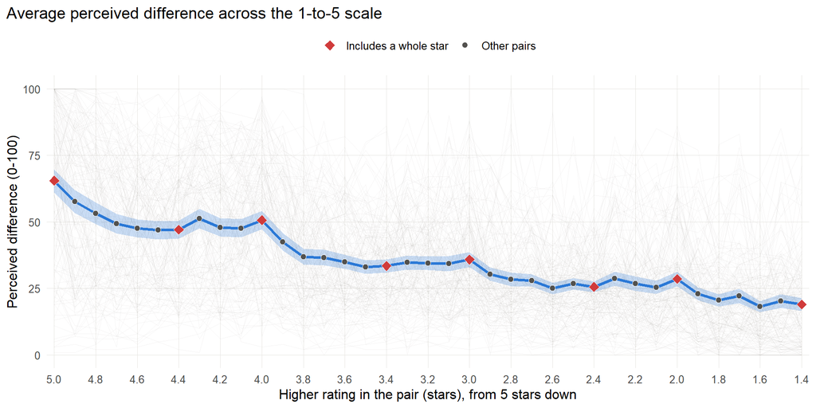

```r
# Place each pair at its higher rating (midpoint + 0.2) for this plot, and mark pairs in
# which either rating is a whole star (e.g. 3.6 vs 4.0, 4.0 vs 4.4)
red <- "#d03b3b"
incl_levels <- c("Includes a whole star", "Other pairs")
long_hi <- mutate(long, x = x + 0.2)
mean_hi <- mean_curve |>
  mutate(lower = round(x - 0.2, 1), higher = round(x + 0.2, 1),
         includes = abs(lower - round(lower)) < 1e-9 | abs(higher - round(higher)) < 1e-9,
         pt_incl = factor(ifelse(includes, incl_levels[1], incl_levels[2]), levels = incl_levels),
         x = higher)
ggplot() +
  geom_line(data = long_hi, aes(x, y, group = id), color = "#9a9893", alpha = 0.10, linewidth = 0.3) +
  geom_ribbon(data = mean_hi, aes(x, ymin = lo, ymax = hi), fill = blue, alpha = 0.25) +
  geom_line(data = mean_hi, aes(x, m), color = blue, linewidth = 1.2) +
  geom_point(data = mean_hi, aes(x, m, fill = pt_incl, shape = pt_incl, size = pt_incl),
             color = "#fcfcfb", stroke = 0.4) +
  scale_fill_manual(values = setNames(c(red, ink2), incl_levels), name = NULL) +
  scale_shape_manual(values = setNames(c(23, 21), incl_levels), name = NULL) +
  scale_size_manual(values = setNames(c(3.2, 2.2), incl_levels), name = NULL) +
  # 5 stars at the origin, ratings decreasing to the right; a tick every 0.2 stars
  scale_x_reverse(breaks = seq(5, 1.4, by = -0.2), labels = \(v) sprintf("%.1f", v),
                  limits = c(5, 1.4), expand = expansion(mult = c(0.01, 0.01))) +
  coord_cartesian(ylim = c(0, 100)) +
  labs(x = "Higher rating in the pair (stars), from 5 stars down",
       y = "Perceived difference (0-100)",
       title = "Average perceived difference across the 1-to-5 scale") +
  theme_pod
```

## Test 2: Where the curve rises

A smooth curve is fitted through all responses (a GAM, allowing each person their own baseline and tilt). The lower panel shows how steep it is at each point. **Shaded spans are where the curve is clearly rising** (the 95% interval of its steepness is above 0).

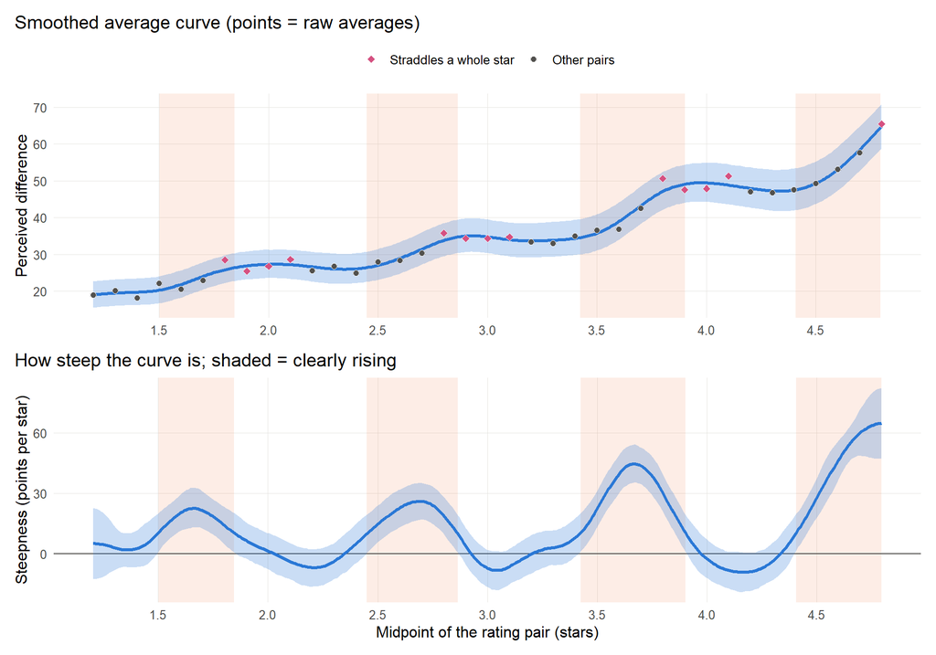

```r
shade <- geom_rect(data = rise_spans, aes(xmin = xmin, xmax = xmax, ymin = -Inf, ymax = Inf),
                   fill = orange, alpha = 0.12)
p1 <- ggplot() + shade +
  geom_ribbon(data = gam_curve, aes(x, ymin = lo, ymax = hi), fill = blue, alpha = 0.25) +
  geom_line(data = gam_curve, aes(x, fit), color = blue, linewidth = 1.1) +
  cross_points(mean_curve, 2) +
  scale_x_continuous(breaks = seq(1, 5, 0.5)) +
  labs(x = NULL, y = "Perceived difference", title = "Smoothed average curve (points = raw averages)") +
  theme_pod
p2 <- ggplot() + shade +
  geom_hline(yintercept = 0, color = ink2, linewidth = 0.4) +
  geom_ribbon(data = gam_deriv, aes(x, ymin = lo, ymax = hi), fill = blue, alpha = 0.25) +
  geom_line(data = gam_deriv, aes(x, d), color = blue, linewidth = 1.1) +
  scale_x_continuous(breaks = seq(1, 5, 0.5)) +
  labs(x = "Midpoint of the rating pair (stars)", y = "Steepness (points per star)",
       title = "How steep the curve is; shaded = clearly rising") +
  theme_pod
p1 / p2
```

**Result.** The curve rises in 4 separate spurts (1.5-1.8, 2.4-2.9, 3.4-3.9, 4.4-4.8 stars) with flat stretches between them. Each spurt ends where pairs begin to straddle a whole star. That staircase shape is what tests 3–6 try to explain.

### Step by step, person by person

**What this adds.** The smooth curve above estimates the slope from the average curve. Here the change is computed **within each person** instead: for every participant, the response to one pair is subtracted from their response to the next pair up the scale (for example, 3.6 vs 4.0 minus 3.5 vs 3.9). Positive = the next pair up feels more different. These 36 step-to-step changes are then averaged across participants.

The average of these changes is mathematically the same as the change in the average curve, so the dots carry no new information. What is new is the **uncertainty**: each step’s 95% interval and test come from how consistently *individuals* change at that step. Each step is placed between the higher ratings of its two pairs, on the same axis as Test 1 (5 stars at the left).

```r
steps <- long |>
  arrange(id, x) |>
  group_by(id) |>
  mutate(change = y - lag(y), from_hi = round(lag(x) + 0.2, 1), to_hi = round(x + 0.2, 1)) |>
  ungroup() |>
  filter(!is.na(change))
step_types <- c("Into a pair that reaches a whole star (e.g. 3.5 vs 3.9 → 3.6 vs 4.0)",
                "Into a pair that starts at a whole star (e.g. 3.9 vs 4.3 → 4.0 vs 4.4)",
                "Other steps")
step_sum <- steps |>
  group_by(from_hi, to_hi) |>
  summarise(n = n(), m = mean(change), med = median(change), se = sd(change) / sqrt(n),
            .groups = "drop") |>
  mutate(lo = m - qt(.975, n - 1) * se, hi = m + qt(.975, n - 1) * se,
         p = 2 * pt(-abs(m / se), n - 1), p_holm = p.adjust(p, "holm"),
         pos = (from_hi + to_hi) / 2,
         type = factor(case_when(abs(to_hi - round(to_hi)) < 1e-9 ~ step_types[1],
                                 abs((to_hi - 0.4) - round(to_hi - 0.4)) < 1e-9 ~ step_types[2],
                                 TRUE ~ step_types[3]), levels = step_types))
# check: the average of individual changes equals the change in the average curve
stopifnot(isTRUE(all.equal(step_sum$m, diff(mean_curve$m))))

step_cols   <- setNames(c(red, blue, ink2), step_types)
step_shapes <- setNames(c(23, 24, 21), step_types)
```

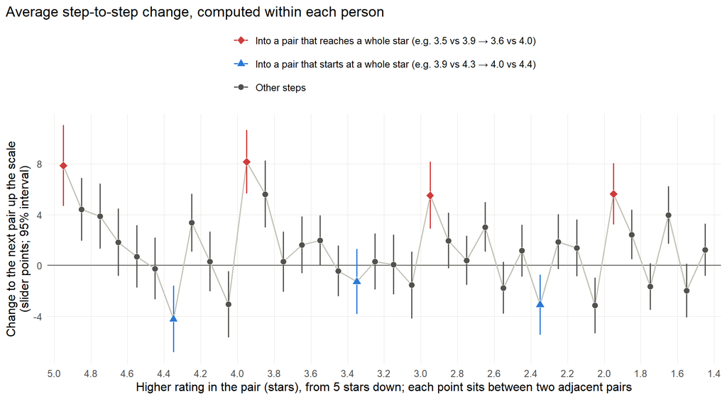

```r
ggplot(step_sum, aes(pos, m)) +
  geom_hline(yintercept = 0, color = ink2, linewidth = 0.4) +
  geom_line(color = "#c3c2b7", linewidth = 0.6) +
  geom_errorbar(aes(ymin = lo, ymax = hi, color = type), width = 0, linewidth = 0.7) +
  geom_point(aes(fill = type, shape = type), color = "#fcfcfb", stroke = 0.4, size = 2.8) +
  scale_color_manual(values = step_cols, name = NULL) +
  scale_fill_manual(values = step_cols, name = NULL) +
  scale_shape_manual(values = step_shapes, name = NULL) +
  scale_x_reverse(breaks = seq(5, 1.4, by = -0.2), labels = \(v) sprintf("%.1f", v),
                  limits = c(5, 1.4), expand = expansion(mult = c(0.01, 0.01))) +
  guides(color = guide_legend(ncol = 1), fill = guide_legend(ncol = 1), shape = guide_legend(ncol = 1)) +
  labs(x = "Higher rating in the pair (stars), from 5 stars down; each point sits between two adjacent pairs",
       y = "Change to the next pair up the scale\n(slider points; 95% interval)",
       title = "Average step-to-step change, computed within each person") +
  theme_pod
```

```r
step_sum |>
  group_by(`Type of step` = type) |>
  summarise(Steps = n(), `Average change (points)` = sprintf("%+.1f", mean(m)),
            `Range across steps` = sprintf("%+.1f to %+.1f", min(m), max(m)),
            `Different from 0 (Holm-corrected p < .05)` = sum(p_holm < .05), .groups = "drop") |>
  kable(align = "lrrrr", caption = "Step-to-step changes by type of step")
```

Step-to-step changes by type of step

| Type of step | Steps | Average change (points) | Range across steps | Different from 0 (Holm-corrected p < .05) |
| --- | --- | --- | --- | --- |
| Into a pair that reaches a whole star (e.g. 3.5 vs 3.9 → 3.6 vs 4.0) | 4 | +6.8 | +5.5 to +8.1 | 4 |
| Into a pair that starts at a whole star (e.g. 3.9 vs 4.3 → 4.0 vs 4.4) | 3 | -2.8 | -4.2 to -1.3 | 0 |
| Other steps | 29 | +1.0 | -3.1 to +5.6 | 3 |

**Result.** With 36 steps tested, a Holm correction is applied so that chance alone is unlikely to produce any significant step.

- **Every step into a pair that reaches a whole star is a clear rise.** All 4 (into 2.0, 3.0, 4.0 and 5.0) go up, by 5.5 to 8.1 points, and all are significant after correction. The rises into 4.0 and 5.0 are the two largest on the whole scale.
- **Every step into a pair that starts at a whole star goes down** (-1.3 to -4.2 points). 2 of the 3 are significant on their own, but none survives the correction, so these drops are suggestive rather than firm.
- **Other steps average a small rise** (+1.0 points), which is the gradual climb across the scale.
- **In words:** the moment a pair reaches a whole star, it feels clearly more different than the pair just below it. Once the pair has moved past the whole star (both ratings at or above it), it feels somewhat less different again. This is the step-by-step view of the jumps modeled in Test 6.

### A simple comparison at each whole star

**Question.** For a whole star such as 2.0, does the pair that **ends** at it (1.6 vs 2.0) feel bigger than the pair that **starts** at it (2.0 vs 2.4)? Both pairs are 0.4 stars apart and share the whole star; they differ only in which side of it they sit on.

**How it is coded.** For each person and each whole star (2, 3 and 4), the comparison is coded **1** if the pair ending at the whole star got the larger response and **0** if it got the smaller one. The average of these codes is the **proportion of people for whom the pair ending at the whole star felt bigger**. 50% would mean no difference.

- **Ties** (the same response to both pairs) are left out of the proportion and counted separately. A version counting ties as 0.5 is shown as a check.
- **Only 2, 3 and 4 stars** can be tested: there is no pair above 5.0 or below 1.0.
- **The test is conservative.** Perceived differences generally grow up the scale (Test 1), which by itself favors the *upper* pair. A proportion above 50% therefore goes against that trend.

```r
ws_cmp <- bind_rows(lapply(2:4, function(k) {
  tibble(id = dat$response_id, star = k,
         ending = dat[[sprintf("d%.1f", k - 0.4)]],     # e.g. 1.6 vs 2.0
         starting = dat[[sprintf("d%.1f", k)]])         # e.g. 2.0 vs 2.4
})) |>
  mutate(code = case_when(ending > starting ~ 1, ending < starting ~ 0, TRUE ~ NA_real_),
         code_half = ifelse(is.na(code), 0.5, code))

ws_by_star <- ws_cmp |>
  group_by(star) |>
  summarise(bigger = sum(code == 1, na.rm = TRUE), smaller = sum(code == 0, na.rm = TRUE),
            ties = sum(is.na(code)), mean_ending = mean(ending), mean_starting = mean(starting),
            .groups = "drop") |>
  rowwise() |>
  mutate(bt = list(binom.test(bigger, bigger + smaller, p = 0.5)),
         prop = bigger / (bigger + smaller),
         lo = bt$conf.int[1], hi = bt$conf.int[2], p = bt$p.value) |>
  ungroup()

# Each person's own proportion across the three whole stars (ties counted as 0.5)
ws_person <- ws_cmp |> group_by(id) |> summarise(score = mean(code_half), .groups = "drop")
ws_person_t <- t.test(ws_person$score, mu = 0.5)
ws_half <- ws_cmp |> group_by(star) |> summarise(prop_half = mean(code_half), .groups = "drop")

ws_by_star |>
  left_join(ws_half, by = "star") |>
  transmute(`Whole star` = star,
            `Pair ending at it` = sprintf("%.1f vs %.1f", star - 0.4, star),
            `Pair starting at it` = sprintf("%.1f vs %.1f", star, star + 0.4),
            `Average response (ending / starting)` = sprintf("%.1f / %.1f", mean_ending, mean_starting),
            `Ending pair bigger / smaller / tie` = sprintf("%d / %d / %d", bigger, smaller, ties),
            `Proportion bigger (ties left out)` = sprintf("%.0f%% (95%% CI %.0f%%-%.0f%%)", 100 * prop, 100 * lo, 100 * hi),
            p = fmt_p(p),
            `Ties counted as 0.5` = sprintf("%.0f%%", 100 * prop_half)) |>
  kable(align = "lllrrrrr",
        caption = "Does the pair ending at a whole star feel bigger than the pair starting at it? (exact binomial test against 50%)")
```

Does the pair ending at a whole star feel bigger than the pair starting at it? (exact binomial test against 50%)

| Whole star | Pair ending at it | Pair starting at it | Average response (ending / starting) | Ending pair bigger / smaller / tie | Proportion bigger (ties left out) | p | Ties counted as 0.5 |
| --- | --- | --- | --- | --- | --- | --- | --- |
| 2 | 1.6 vs 2.0 | 2.0 vs 2.4 | 28.6 / 25.6 | 89 / 70 / 8 | 56% (95% CI 48%-64%) | .153 | 56% |
| 3 | 2.6 vs 3.0 | 3.0 vs 3.4 | 35.9 / 33.5 | 91 / 71 / 5 | 56% (95% CI 48%-64%) | .135 | 56% |
| 4 | 3.6 vs 4.0 | 4.0 vs 4.4 | 50.7 / 47.1 | 94 / 63 / 10 | 60% (95% CI 52%-68%) | .016 | 59% |

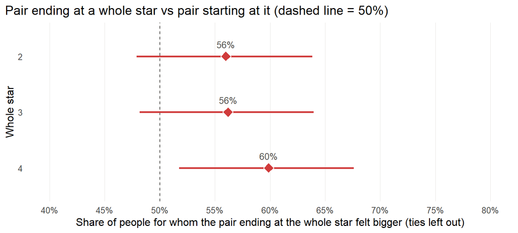

```r
ggplot(ws_by_star, aes(x = prop, y = factor(star, levels = 4:2))) +
  geom_vline(xintercept = 0.5, color = ink2, linewidth = 0.5, linetype = "dashed") +
  geom_errorbar(aes(xmin = lo, xmax = hi), width = 0, color = red, linewidth = 0.9, orientation = "y") +
  geom_point(shape = 23, fill = red, color = "#fcfcfb", size = 4) +
  geom_text(aes(label = sprintf("%.0f%%", 100 * prop)), vjust = -1.2, size = 3.6, color = ink2) +
  scale_x_continuous(labels = \(v) paste0(round(100 * v), "%"), limits = c(0.4, 0.8),
                     breaks = seq(0.4, 0.8, 0.05)) +
  labs(x = "Share of people for whom the pair ending at the whole star felt bigger (ties left out)",
       y = "Whole star",
       title = "Pair ending at a whole star vs pair starting at it (dashed line = 50%)") +
  theme_pod + theme(panel.grid.major.y = element_blank())
```

**Result.**

- **2 stars:** 56% of people (ties left out) felt 1.6 vs 2.0 was bigger than 2.0 vs 2.4 (*p* = .153).
- **3 stars:** 56% (*p* = .135).
- **4 stars:** 60% (*p* = .016).
- **Across all three, per person:** on average, people judged the pair ending at the whole star bigger in 57% of their three comparisons (ties as half; 95% CI 52%-62%, *p* = .003 against 50%).
- **Ties were rare** (5% of all comparisons), and counting them as half changes nothing meaningful.
- **In words:** at each whole star, a small majority of people feel the pair that reaches it is bigger than the pair that starts at it, even though the general rise in sensitivity favors the opposite. On its own, only 4 stars is clearly above 50%. Taken together across 2, 3 and 4, the tendency is reliable. This simple count tells the same story as the step-by-step and Test 6 analyses, with 4 stars again the strongest.

## Test 3: How many regions?

Each row is one model. **Prediction error** is the main measure (lower = better): how far the curve fitted on one half of participants misses the other half. **Best in % of splits** is how often that model had the lowest error among the region models. The last row is a benchmark that reuses half A’s raw averages with no model at all.

**All 37 pairs**

```r
show_compare(R_all)
```

| Model | Breaks (all participants) | Prediction error | Best in % of splits | Δ BIC |
| --- | --- | --- | --- | --- |
| Straight line (1 region) | - | 14.9 | 0% | 198.3 |
| Step, 2 regions (1 break) | 3.65 | 10.9 | 0% | 84.5 |
| Step, 3 regions (2 breaks) | 3.75, 4.35 | 7.0 | 23% | 0.0 |
| Step, 4 regions (3 breaks) | 2.15, 3.75, 4.35 | 6.9 | 58% | 8.5 |
| Elbow, 2 regions (1 break) | 3.35 | 11.4 | 0% | 101.7 |
| Elbow, 3 regions (2 breaks) | 3.30, 4.40 | 10.7 | 0% | 93.8 |
| Elbow, 4 regions (3 breaks) | 3.35, 3.85, 4.35 | 7.8 | 4% | 34.5 |
| Whole-star bumps on a straight-line trend (Appendix D) | - | 8.1 | 15% | 20.6 |
| No model: half A’s raw means | - | 5.0 | - | - |

**Without the top pair (4.6 vs 5.0)**

```r
show_compare(R_cut)
```

| Model | Breaks (all participants) | Prediction error | Best in % of splits | Δ BIC |
| --- | --- | --- | --- | --- |
| Straight line (1 region) | - | 11.5 | 0% | 110.2 |
| Step, 2 regions (1 break) | 3.65 | 8.0 | 2% | 17.2 |
| Step, 3 regions (2 breaks) | 3.75, 4.25 | 7.0 | 22% | 0.0 |
| Step, 4 regions (3 breaks) | 2.15, 3.75, 4.25 | 6.8 | 60% | 7.6 |
| Elbow, 2 regions (1 break) | 3.30 | 9.6 | 0% | 63.5 |
| Elbow, 3 regions (2 breaks) | 3.40, 3.85 | 8.3 | 0% | 38.3 |
| Elbow, 4 regions (3 breaks) | 2.85, 3.35, 3.85 | 8.2 | 2% | 46.2 |
| Whole-star bumps on a straight-line trend (Appendix D) | - | 8.0 | 12% | 18.3 |
| No model: half A’s raw means | - | 4.8 | - | - |

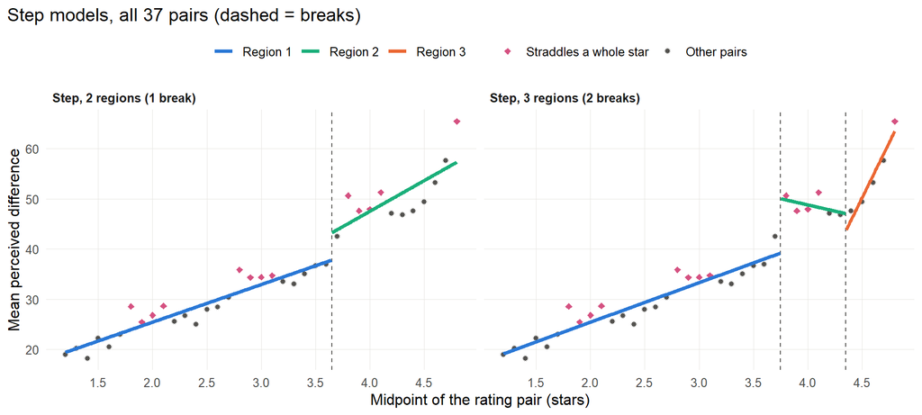

```r
plot_fits(R_all, c("step1", "step2"), "Step models, all 37 pairs (dashed = breaks)")
```

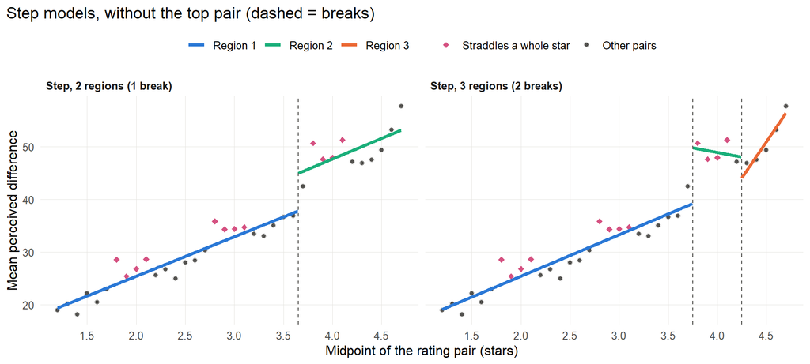

```r
plot_fits(R_cut, c("step1", "step2"), "Step models, without the top pair (dashed = breaks)")
```

**Result.**

- **3 regions beat 2.** The 3-region step model predicts new participants clearly better than the 2-region one, with all pairs (7.0 vs 10.9) and without the top pair (7.0 vs 8.0). BIC agrees.
- **4 regions barely help.** The 4-region model is best in more splits, but by a hair (6.9 vs 7.0). Its extra break (2.15) just follows the bump where pairs cross 2 stars, and BIC prefers 3 regions. Three is the best balance.
- **Jumps beat bends.** Every step model predicts better than the elbow model with the same number of regions.
- **The 3-region step model beats whole-star bumps on a straight-line trend** (7.0 vs 8.1). But Test 6 shows that whole-star jumps on a *curved* trend beat every region model.
- **No region model matches the raw averages** (5.0). Some pair-to-pair detail repeats across halves of the sample but is finer than straight-line regions can capture. Test 6 gets much closer.

## Test 4: Where the boundaries are, and how stable they are

For each break, the table shows its best estimate and how often it lands in the same spot when participants are re-drawn. **At the allowed limit** is how often a break sits at the edge of where the method can put it (each region needs 5 pairs). A break that piles up there is trying to isolate the scale’s end, not marking a boundary.

**All 37 pairs**

```r
show_breaks(R_all, c("step1", "step2"))
```

| Model | Break | Best estimate | 95% range | Same spot | Within 0.1 star | At the allowed limit |
| --- | --- | --- | --- | --- | --- | --- |
| Step, 2 regions (1 break) | Only break | 3.65 | 3.65-4.35 | 67% | 76% | 22% |
| Step, 3 regions (2 breaks) | Lower break | 3.75 | 3.65-3.75 | 81% | 99% | 0% |
| Step, 3 regions (2 breaks) | Upper break | 4.35 | 4.25-4.35 | 92% | 98% | 92% |

**Without the top pair**

```r
show_breaks(R_cut, c("step1", "step2"))
```

| Model | Break | Best estimate | 95% range | Same spot | Within 0.1 star | At the allowed limit |
| --- | --- | --- | --- | --- | --- | --- |
| Step, 2 regions (1 break) | Only break | 3.65 | 3.65-3.75 | 63% | 100% | 0% |
| Step, 3 regions (2 breaks) | Lower break | 3.75 | 2.75-3.75 | 54% | 90% | 0% |
| Step, 3 regions (2 breaks) | Upper break | 4.25 | 3.65-4.25 | 67% | 95% | 67% |

**Result.** The 3-region model’s first boundary is stable: with all pairs it lands at 3.75 in 81% of re-draws and within 0.1 stars in 99%. Without the top pair it is less sharply pinned (within 0.1 stars in 90%). The second boundary sits at the allowed limit in most re-draws (92% with all pairs, 67% without the top pair), so it marks where the climb toward 5 stars begins. The 2-region model’s single break (3.65) wanders much more with all pairs (95% range 3.65-4.35): with only one break, it is pulled between the jump near 4 stars and the climb at the top.

## Test 5: Slopes within regions

Is the slope in each region of the 3-region step model (the best-fitting region model) different from 0? Intervals and *p*-values come from the bootstrap, which re-finds the breaks each time, so they include the uncertainty about where the regions are. The 2-region model’s slopes are in Appendix B.

**All 37 pairs**

```r
show_slopes(R_all, "step2")
```

| Model | Region | Span (stars) | Slope | 95% CI | p | Differs from 0? |
| --- | --- | --- | --- | --- | --- | --- |
| Step, 3 regions (2 breaks) | Region 1 | 1.20-3.75 | 7.9 | 6.6 to 8.9 | < .0005 | yes |
| Step, 3 regions (2 breaks) | Region 2 | 3.75-4.35 | -5.0 | -9.8 to 9.9 | .383 | no |
| Step, 3 regions (2 breaks) | Region 3 | 4.35-4.80 | 44.1 | 33.2 to 51.8 | < .0005 | yes |

**Without the top pair**

```r
show_slopes(R_cut, "step2")
```

| Model | Region | Span (stars) | Slope | 95% CI | p | Differs from 0? |
| --- | --- | --- | --- | --- | --- | --- |
| Step, 3 regions (2 breaks) | Region 1 | 1.20-3.75 | 7.9 | 6.5 to 9.8 | < .0005 | yes |
| Step, 3 regions (2 breaks) | Region 2 | 3.75-4.25 | -3.5 | -8.4 to 24.5 | .985 | no |
| Step, 3 regions (2 breaks) | Region 3 | 4.25-4.70 | 27.3 | 6.0 to 34.2 | < .0005 | yes |

**Result.** The slope is clearly positive below the first boundary and in the top region, and **not different from 0 in the middle region**, with all pairs and without the top pair.

Two further checks of the same slopes are in Appendix B: a mixed model on all individual responses, and a split-half test. They agree that the first and last regions rise, and neither finds the middle slope different from 0. The closest is the mixed model with all pairs (slightly negative, *p* = .055).

## Test 6: A model of how good each rating feels (β-δ)

### The idea

Tests 3–5 fit straight lines to the *differences* people report. That describes the curve but does not say why it looks the way it does. This test goes one level deeper and models **how good each rating feels**, then derives the differences from that.

The model borrows its structure from quasi-hyperbolic (β-δ) discounting and from left-digit models of prices (Thomas & Morwitz, 2005) and odometer readings (Lacetera, Pope & Sydnor, 2012). Each combines two ingredients:

- **δ, a smooth part:** how sensitive people are to a change in rating at each point on the scale.
- **β, jumps:** a one-off step up in how good a rating feels when it reaches a privileged point. Here the candidates are the whole stars 2, 3, 4 and 5.

**Why this matters for reading the curve.** The task measures *differences* between two ratings 0.4 stars apart. A jump in value at, say, 4 stars only affects pairs that straddle 4 (3.6 vs 4.0 through 3.9 vs 4.3). Those four pairs feel bigger, and the curve then drops back. That is exactly the magenta blocks in the plots. A change in *sensitivity* would instead make differences stay bigger from that point on. The two ingredients therefore leave different fingerprints, and the model can tell them apart.

### The model

$$\text{response}(a) = \text{offset} + u(a + 0.4) - u(a)$$

$$u(r) = \lambda \cdot \big[-\log(T - r)\big] + \beta_2\,\mathbf{1}[r \ge 2] + \beta_3\,\mathbf{1}[r \ge 3] + \beta_4\,\mathbf{1}[r \ge 4] + \beta_5\,\mathbf{1}[r \ge 5]$$

- $a$ = the lower rating in a pair (1.0 to 4.6 stars); the higher rating is $a + 0.4$.
- $\text{response}(a)$ = the average perceived difference for that pair, on the 0–100 slider.
- $r$ = any star rating from 1 to 5.
- $u(r)$ = how good rating $r$ feels (its perceived value), in slider points. Only differences in $u$ matter, so its zero point is arbitrary.
- $\text{offset}$ = a constant that absorbs how people use the slider overall. It shifts every response equally and does not affect the shape.
- $\lambda$ (lambda) = the strength of the smooth part: how many slider points a change in rating is worth, overall.
- $T$ = the anchor of the “distance from perfect” curve, in stars (above 5). The term $-\log(T - r)$ rises faster as $r$ approaches $T$, so sensitivity grows toward the top of the scale. A larger $T$ means gentler curvature; as $T$ grows very large the curve becomes a straight line.
- $\log$ = natural logarithm.
- $\beta_2, \beta_3, \beta_4, \beta_5$ (beta) = the size of the jump in value, in slider points, when a rating reaches 2, 3, 4 or 5 stars.
- $\mathbf{1}[r \ge k]$ = 1 if rating $r$ is at least $k$ stars, otherwise 0. It switches the jump on.

The **left-digit** version replaces every rating $r$ with $\hat r = \lfloor r \rfloor + (1 - \theta)(r - \lfloor r \rfloor)$ inside the smooth part and drops the separate jumps:

- $\lfloor r \rfloor$ = the whole-star part of $r$ (for 3.7, it is 3).
- $\theta$ (theta) = the share of the decimal part that people ignore, between 0 and 1. With $\theta = 0.1$, a 3.7 is read as $3 + 0.9 \times 0.7 = 3.63$.
- $\hat r$ = the rating as perceived. Ignoring part of the decimal creates a jump at every whole star automatically. Its size is set by $\theta$ and by how sensitive people are at that point, so one number explains all the jumps.

**How it is fitted.** As with the region models, the few shape settings ($T$, and $\theta$ for the left-digit version) are found by trying a grid of values and keeping the best fit. Everything else is then estimated directly. Models are compared with the same prediction test (the same 200 half-splits as Test 3), and uncertainty comes from the same participant bootstrap.

The model is built up in four steps. Each adds one ingredient and keeps it only if it improves prediction.

### Step 1: The smooth part. Which way does sensitivity change?

**Question.** Ignoring jumps, how does sensitivity change along the scale?

**Why.** Different theories predict different shapes. Weber’s law, the classic account of perception, says people are *most* sensitive at the bottom of a scale, so differences should shrink as ratings rise. A “distance from perfect” reading says people judge a rating by how far it falls short of 5, so differences should grow near the top. A straight line is the neutral benchmark.

```r
show_lev <- function(keys) lev_cmp |>
  filter(key %in% keys) |>
  arrange(match(key, keys)) |>
  transmute(Model = lev_labels[key], `Prediction error` = sprintf("%.1f", err),
            `Δ BIC` = ifelse(is.na(dBIC), "-", sprintf("%.1f", dBIC))) |>
  kable(align = "lrr")
show_lev(c("flat", "linear", "weber", "perfect"))
```

| Model | Prediction error | Δ BIC |
| --- | --- | --- |
| Flat: same sensitivity everywhere | 141.8 | 3095.1 |
| Straight-line rise | 14.9 | 269.7 |
| Weber-Fechner: most sensitive at the bottom | 42.4 | 1000.9 |
| Distance from perfect: most sensitive near 5 | 11.3 | 171.1 |

**Result.** “Distance from perfect” predicts best (11.3, against 14.9 for a straight line). Weber’s law fits far worse than a straight line (42.4): it predicts the wrong direction. Sensitivity **grows** toward the top of the scale. This smooth curve is used in all later steps.

### Step 2: Jumps at whole stars

**Question.** On top of the smooth part, does value jump when a rating reaches a whole star? Are the jumps the same size at every whole star?

```r
show_lev(c("perfect", "beta", "shared", "b23", "leftdig"))
```

| Model | Prediction error | Δ BIC |
| --- | --- | --- |
| Distance from perfect: most sensitive near 5 | 11.3 | 171.1 |
| + separate jump at 2, 3, 4 and 5 | 5.3 | 16.2 |
| + one shared jump at 2, 3, 4 (own jump at 5) | 5.8 | 17.7 |
| + equal jumps at 2 and 3, own jumps at 4 and 5 | 5.3 | 7.5 |
| + left-digit: one inattention setting makes every jump | 5.4 | 0.0 |

**Jump sizes** (separate-jumps model; slider points; 95% intervals from the bootstrap):

```r
tibble(`Whole star` = 2:5) |>
  mutate(Jump = sapply(`Whole star`, \(k) fb$coef[[paste0("beta", k)]]),
         `95% CI` = sapply(`Whole star`, \(k) ci(bb[[paste0("beta", k)]])),
         p = sapply(`Whole star`, \(k) pboot(bb[[paste0("beta", k)]])),
         `Left-digit model implies` = ld_vs_free$implied) |>
  mutate(Jump = sprintf("%.1f", Jump), `Left-digit model implies` = sprintf("%.1f", `Left-digit model implies`),
         `Whole star` = ifelse(`Whole star` == 5, "5 (also the end of the scale)", as.character(`Whole star`))) |>
  kable(align = "lrrrr")
```

| Whole star | Jump | 95% CI | p | Left-digit model implies |
| --- | --- | --- | --- | --- |
| 2 | 3.8 | 2.5 to 5.0 | < .0005 | 3.9 |
| 3 | 3.7 | 2.1 to 5.1 | < .0005 | 4.7 |
| 4 | 7.0 | 5.4 to 8.5 | < .0005 | 6.0 |
| 5 (also the end of the scale) | 8.2 | 5.3 to 11.0 | < .0005 | 8.0 |

**Are the jumps different from each other?**

```r
contr |>
  transmute(Comparison, Difference = sprintf("%.1f", est), `95% CI` = sapply(draws, ci),
            p = sapply(draws, pboot)) |>
  kable(align = "lrrr")
```

| Comparison | Difference | 95% CI | p |
| --- | --- | --- | --- |
| Jump at 4 minus jump at 2 | 3.2 | 1.7 to 4.8 | < .0005 |
| Jump at 4 minus jump at 3 | 3.3 | 1.9 to 4.7 | < .0005 |
| Jump at 3 minus jump at 2 | -0.1 | -1.6 to 1.3 | .879 |
| Jump at 5 minus jump at 4 | 1.2 | -2.0 to 4.3 | .443 |

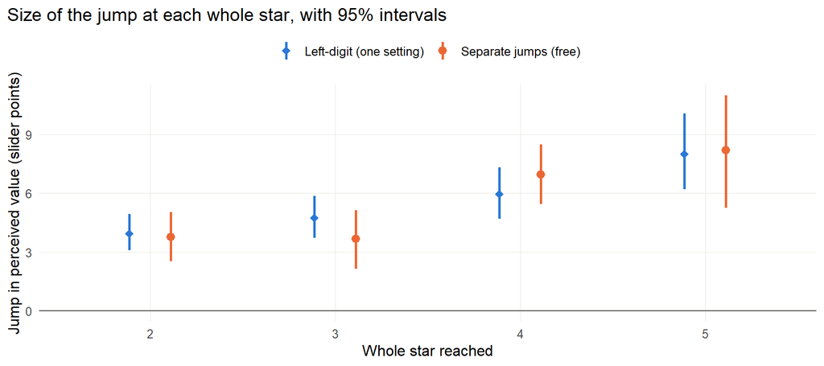

```r
jump_df <- bind_rows(
  tibble(k = 2:5, est = sapply(2:5, \(s) fb$coef[[paste0("beta", s)]]),
         lo = sapply(2:5, \(s) quantile(bb[[paste0("beta", s)]], .025)),
         hi = sapply(2:5, \(s) quantile(bb[[paste0("beta", s)]], .975)),
         model = "Separate jumps (free)"),
  tibble(k = 2:5, est = ld_vs_free$implied,
         lo = sapply(2:5, \(s) quantile(ld_jump_draw(s), .025)),
         hi = sapply(2:5, \(s) quantile(ld_jump_draw(s), .975)),
         model = "Left-digit (one setting)"))
ggplot(jump_df, aes(x = factor(k), y = est, color = model, shape = model)) +
  geom_hline(yintercept = 0, color = ink2, linewidth = 0.4) +
  geom_pointrange(aes(ymin = lo, ymax = hi), position = position_dodge(width = 0.45),
                  size = 0.6, linewidth = 0.9) +
  scale_color_manual(values = c(`Separate jumps (free)` = orange, `Left-digit (one setting)` = blue), name = NULL) +
  scale_shape_manual(values = c(`Separate jumps (free)` = 16, `Left-digit (one setting)` = 18), name = NULL) +
  labs(x = "Whole star reached", y = "Jump in perceived value (slider points)",
       title = "Size of the jump at each whole star, with 95% intervals") +
  theme_pod
```

**Does one left-digit setting explain every jump?** Each row compares a freely estimated jump with what the left-digit model implies for the same re-drawn sample:

```r
ld_vs_free |>
  transmute(`Whole star` = k, `Free jump` = sprintf("%.1f", free),
            `Left-digit implies` = sprintf("%.1f", implied),
            `Free minus implied` = sprintf("%.1f", free - implied),
            `95% CI` = sapply(draws, ci), p = sapply(draws, pboot)) |>
  kable(align = "rrrrrr")
```

| Whole star | Free jump | Left-digit implies | Free minus implied | 95% CI | p |
| --- | --- | --- | --- | --- | --- |
| 2 | 3.8 | 3.9 | -0.2 | -1.2 to 0.7 | .636 |
| 3 | 3.7 | 4.7 | -1.1 | -2.0 to -0.3 | .009 |
| 4 | 7.0 | 6.0 | 1.0 | -0.0 to 2.0 | .060 |
| 5 | 8.2 | 8.0 | 0.2 | -2.3 to 2.5 | .941 |

**Result.**

- **Jumps matter.** Adding them roughly halves the prediction error (5.3 vs 11.3 for the smooth part alone).
- **2 and 3 stars have the same jump** (3.8 and 3.7 points, difference *p* = .879).
- **4 stars is a bigger jump**, about twice as large (7.0 points; larger than at 2 and at 3, both *p* < .0005).
- **5 stars** (8.2) is not clearly larger than 4 (*p* = .443). It also sits at the end of the scale, so its meaning is ambiguous.
- **Left-digit is close but not complete.** One inattention setting ($\theta$ = 0.040, 95% CI 0.030-0.055) predicts almost as well (5.4) and has the best BIC. In words: people discount about 4% of the decimal part relative to the whole star. It matches the free jumps at 2 and 5 stars. But it **overstates the jump at 3** (by 1.1 points, *p* = .009) and **understates the jump at 4** (by 1.0 points, *p* = .060, borderline). So 3 stars is a weaker boundary, and 4 stars a stronger one, than a pure left-digit effect predicts.

#### Is the 4-star jump above and beyond left-digit bias?

**Question.** A left-digit effect alone creates a jump at every whole star. Once that effect is accounted for, do pairs that cross 4 stars still feel *extra* different?

**Why this test.** The comparison above sets each free jump against what the left-digit model implies, one star at a time. A cleaner way is to test it inside one model: the left-digit model plus one extra term that switches on only for pairs that cross 4 stars. If 4 stars is just another digit change, that extra term should be 0.

$$\text{response}(a) = \text{offset} + \lambda\big[-\log(T - \hat b) + \log(T - \hat a)\big] + \gamma_4\,\mathbf{1}[a < 4 \le a + 0.4]$$

- $a$ = the lower rating in a pair; $a + 0.4$ = the higher rating.
- $\text{response}(a)$ = the average perceived difference for that pair (0–100 slider).
- $\hat a$, $\hat b$ = the two ratings as perceived under the left-digit effect: $\hat r = \lfloor r \rfloor + (1 - \theta)(r - \lfloor r \rfloor)$, where $\lfloor r \rfloor$ is the whole-star part of $r$ and $\theta$ (theta) is the share of the decimal that is ignored. $\theta$ is estimated from the data.
- $\text{offset}$, $\lambda$ (lambda), $T$ = as in the main model: a constant, the strength of the smooth rise, and the anchor of the “distance from perfect” curve.
- $\mathbf{1}[a < 4 \le a + 0.4]$ = 1 if the pair crosses 4 stars (3.6 vs 4.0 through 3.9 vs 4.3), otherwise 0.
- $\gamma_4$ (gamma) = **the extra jump at 4 stars, in slider points, beyond what the left-digit effect produces.** This is the quantity being tested.

```r
x4 <- bx4$extra4
tibble(Quantity = c("Share of the decimal ignored (θ)", "Extra jump at 4 stars (γ4), slider points"),
       Estimate = c(sprintf("%.1f%%", 100 * fx4$grid$theta), sprintf("%.1f", fx4$coef[["extra4"]])),
       `95% CI` = c(sprintf("%.1f%% to %.1f%%", 100 * quantile(bx4$theta, .025), 100 * quantile(bx4$theta, .975)),
                    ci(x4)),
       p = c("-", pboot(x4))) |>
  kable(align = "lrrr", caption = "Left-digit model with an extra jump at 4 stars (95% bootstrap intervals)")
```

Left-digit model with an extra jump at 4 stars (95% bootstrap intervals)

| Quantity | Estimate | 95% CI | p |
| --- | --- | --- | --- |
| Share of the decimal ignored (θ) | 4.0% | 2.5% to 5.0% | - |
| Extra jump at 4 stars (γ4), slider points | 1.7 | 0.3 to 3.3 | .017 |

**The 31% benchmark.** As a benchmark from outside this study, the left-digit model is refitted with the discount **fixed at 31%** instead of the 4% estimated here (31% of the decimal ignored, 69% kept, so 3.9 is read as 3 + 0.69 × 0.9 = 3.62). The table shows the jump each version implies at every whole star, in slider points: how much more different a pair that crosses that whole star feels than the smooth rise alone predicts.

```r
tibble(`Whole star` = c("2", "3", "4", "5 (also the end of the scale)"),
       `Observed (separate jumps)` = sprintf("%.1f", sapply(2:5, \(k) fb$coef[[paste0("beta", k)]])),
       `Left-digit, discount estimated` = sprintf("%.1f", ldest_implied),
       `Left-digit, discount fixed at 31%` = sprintf("%.1f", ld31_implied)) |>
  kable(align = "lrrr", caption = sprintf(
    "Jump implied at each whole star. Prediction error (lower = better): estimated discount %.1f, fixed 31%% %.1f",
    lerr("leftdig"), lerr("ld31")))
```

Jump implied at each whole star. Prediction error (lower = better): estimated discount 5.4, fixed 31% 46.3

| Whole star | Observed (separate jumps) | Left-digit, discount estimated | Left-digit, discount fixed at 31% |
| --- | --- | --- | --- |
| 2 | 3.8 | 3.9 | 6.9 |
| 3 | 3.7 | 4.7 | 9.4 |
| 4 | 7.0 | 6.0 | 14.7 |
| 5 (also the end of the scale) | 8.2 | 8.0 | 34.7 |

**Result.**

- **The jump at 4 stars goes beyond left-digit bias.** With the left-digit effect in the model (4.0% of the decimal ignored), pairs that cross 4 stars still feel 1.7 slider points more different than it predicts (95% CI 0.3 to 3.3, *p* = .017). So 4 stars is more than just another change in the leading digit.
- **The extra jump is real but small.** Adding it does not improve prediction of new participants (5.4 with it, 5.4 without), and BIC slightly prefers the model without it (Δ BIC 3.6). The left-digit effect explains most of what happens at 4 stars; the extra 1.7 points are detectable but modest.
- **A 31% discount does not fit these data.** It predicts jumps about two to four times larger than people show (for example 14.7 points at 4 stars, against 7.0 observed), and its prediction error is 46.3 against 5.4 with the discount estimated. Measured against a 31% benchmark, the 4-star jump would look *smaller* than left-digit bias predicts, but only because 31% overstates every jump. Discounts estimated for prices or similar numbers need not carry over to tenths of a star.

### Step 3: A lasting shift in sensitivity?

**Question.** Besides the jump at 4, do differences stay larger from some point onward, as the region models suggested?

**Why.** A lasting shift would mean people become more sensitive above a threshold, which is a different claim from a one-off jump. This step adds a shift that starts at a point $r^*$ (searched from 2.0 to 4.6 stars) and stays on above it.

- $r^*$ = the rating where sensitivity would change, in stars.

```r
show_lev(c("beta", "shift"))
```

| Model | Prediction error | Δ BIC |
| --- | --- | --- |
| + separate jump at 2, 3, 4 and 5 | 5.3 | 16.2 |
| + separate jumps + lasting sensitivity shift | 5.5 | 26.8 |

**Result.** No. The shift does not improve prediction (5.5 vs 5.3 without it), and its best location is $r^*$ = 4.60 stars: the top of the range searched, not near 4. The “differences stay bigger after 4” pattern in the region models is explained by the smooth rise in sensitivity plus the one-off jump at 4.

### Step 4: Comparison with the region models

**Question.** Does this model describe the curve better than the three-region step model from Test 3?

```r
lev_cmp |>
  arrange(match(key, c("flat", "linear", "weber", "perfect", "beta", "shared", "b23",
                       "leftdig", "ldx4", "shift", "linbeta", "ld31", "step2", "raw means"))) |>
  transmute(Stage = lev_stage[key], Model = lev_labels[key],
            `Prediction error` = sprintf("%.1f", err),
            `Best in % of splits` = ifelse(key == "raw means", "-", sprintf("%.0f%%", 100 * wins)),
            `Δ BIC` = ifelse(is.na(dBIC), "-", sprintf("%.1f", dBIC))) |>
  kable(align = "llrrr")
```

| Stage | Model | Prediction error | Best in % of splits | Δ BIC |
| --- | --- | --- | --- | --- |
| 1. Smooth part | Flat: same sensitivity everywhere | 141.8 | 0% | 3095.1 |
| 1. Smooth part | Straight-line rise | 14.9 | 0% | 269.7 |
| 1. Smooth part | Weber-Fechner: most sensitive at the bottom | 42.4 | 0% | 1000.9 |
| 1. Smooth part | Distance from perfect: most sensitive near 5 | 11.3 | 0% | 171.1 |
| 2. Jumps | + separate jump at 2, 3, 4 and 5 | 5.3 | 6% | 16.2 |
| 2. Jumps | + one shared jump at 2, 3, 4 (own jump at 5) | 5.8 | 2% | 17.7 |
| 2. Jumps | + equal jumps at 2 and 3, own jumps at 4 and 5 | 5.3 | 39% | 7.5 |
| 2. Jumps | + left-digit: one inattention setting makes every jump | 5.4 | 16% | 0.0 |
| 2. Jumps | + left-digit + extra jump at 4 | 5.4 | 13% | 3.6 |
| 3. Sensitivity shift | + separate jumps + lasting sensitivity shift | 5.5 | 20% | 26.8 |
| Benchmarks | Straight-line rise + separate jumps (Appendix D) | 8.1 | 0% | 92.0 |
| Benchmarks | Left-digit with the decimal discount fixed at 31% | 46.3 | 0% | 1117.2 |
| Benchmarks | Region model: step, 3 regions (Test 3) | 7.0 | 4% | 71.5 |
| Benchmarks | No model: half A’s raw averages | 5.0 | - | - |

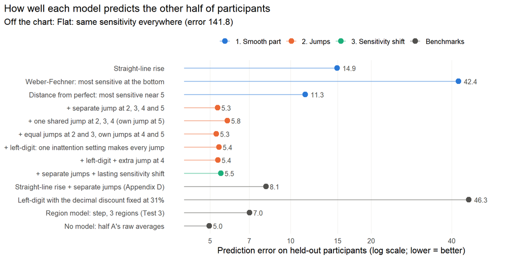

```r
off_chart <- filter(lev_cmp, err > 60)
lev_cmp |>
  filter(err <= 60) |>
  mutate(Model = factor(lev_labels[key], levels = rev(lev_labels[c("linear", "weber", "perfect", "beta", "shared",
                                                               "b23", "leftdig", "ldx4", "shift", "linbeta", "ld31",
                                                               "step2", "raw means")])),
         Stage = lev_stage[key]) |>
  ggplot(aes(x = err, y = Model, color = Stage)) +
  geom_segment(aes(x = 4, xend = err, yend = Model), linewidth = 0.6, alpha = 0.5) +
  geom_point(size = 3.2) +
  geom_text(aes(label = sprintf("%.1f", err)), hjust = -0.4, size = 3.4, color = ink2) +
  scale_x_log10(breaks = c(5, 7, 10, 15, 20, 40), limits = c(4, 60)) +
  scale_color_manual(values = c(`1. Smooth part` = blue, `2. Jumps` = orange,
                                `3. Sensitivity shift` = aqua, Benchmarks = ink2), name = NULL) +
  labs(x = "Prediction error on held-out participants (log scale; lower = better)", y = NULL,
       title = "How well each model predicts the other half of participants",
       subtitle = paste0("Off the chart: ", paste(sprintf("%s (error %.1f)", lev_labels[off_chart$key], off_chart$err),
                                                 collapse = "; "))) +
  theme_pod + theme(panel.grid.major.y = element_blank())
```

### Step 5: What the model says

**The fitted curve.** The orange line is the full model; the dashed blue line is its smooth part alone. The gap between them is the jumps, which appear exactly at the magenta blocks.

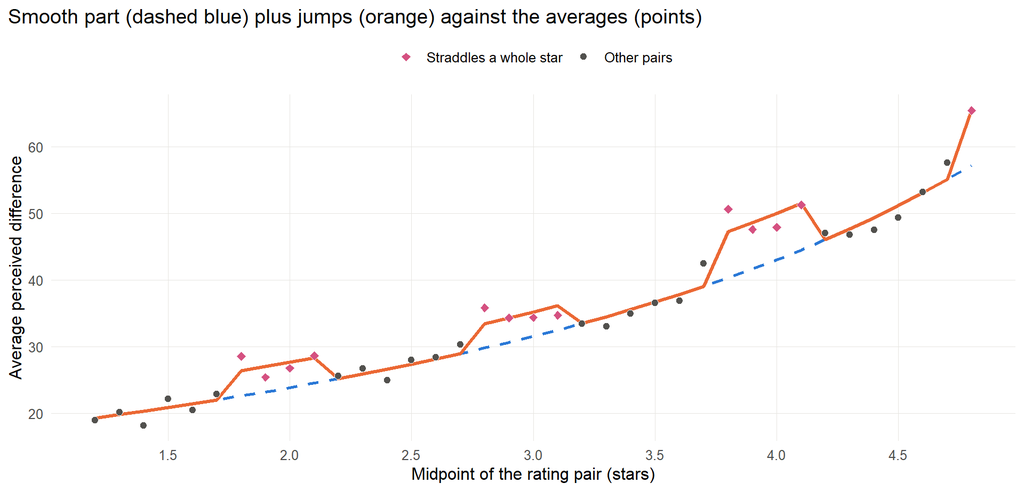

```r
p_fit <- tibble(x = L_all$xv, full = fb$fitted,
                smooth = fb$coef[["offset"]] + fb$coef[["lambda"]] * perf(round(L_all$xv - 0.2, 1), round(L_all$xv + 0.2, 1), fb$grid$c))
ggplot() +
  geom_line(data = p_fit, aes(x, smooth), color = blue, linewidth = 1, linetype = "dashed") +
  geom_line(data = p_fit, aes(x, full), color = orange, linewidth = 1.2) +
  cross_points(mean_curve, 2.2) +
  scale_x_continuous(breaks = seq(1, 5, 0.5)) +
  labs(x = "Midpoint of the rating pair (stars)", y = "Average perceived difference",
       title = "Smooth part (dashed blue) plus jumps (orange) against the averages (points)") +
  theme_pod
```

**How good each rating feels.** This is the value curve $u(r)$ the model implies. Panel A rescales it so a 1-star rating = 0 and a 5-star rating = 100. Panel B removes the smooth rise to show where the whole-star effects sit, on the same 0–100 scale. Read panel B with the note below the figure.

- $u(r)$ = perceived value of rating $r$, rescaled to run from 0 (1 star) to 100 (5 stars).

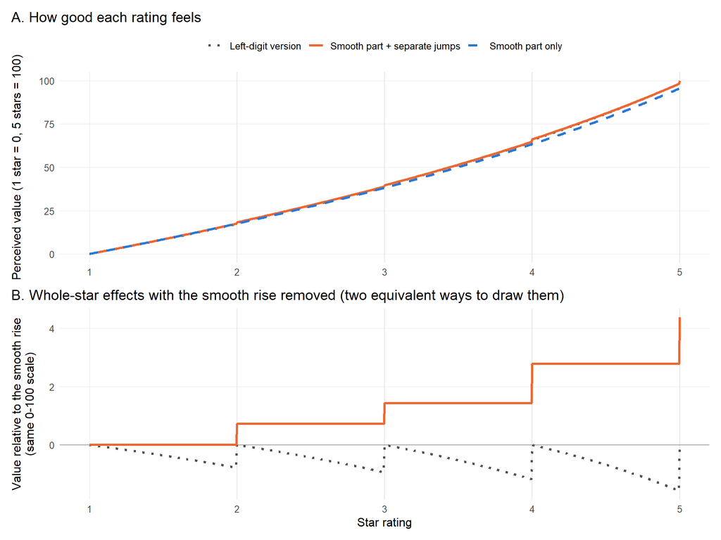

```r
rr <- seq(1, 5, by = 0.005)
lead_hat_v <- \(v, th) fl(v) + (1 - th) * (v - fl(v))
sm_free <- fb$coef[["lambda"]] * (u_perf(rr, fb$grid$c) - u_perf(1, fb$grid$c))
jumps_free <- fb$coef[["beta2"]] * (rr >= 2) + fb$coef[["beta3"]] * (rr >= 3) +
  fb$coef[["beta4"]] * (rr >= 4) + fb$coef[["beta5"]] * (rr >= 5 - 1e-9)
u_free <- sm_free + jumps_free
sm_ld <- fl_ld$coef[["lambda"]] * (u_perf(rr, fl_ld$grid$c) - u_perf(1, fl_ld$grid$c))
u_ld  <- fl_ld$coef[["lambda"]] * (u_perf(lead_hat_v(rr, fl_ld$grid$theta), fl_ld$grid$c) - u_perf(1, fl_ld$grid$c))
k_free <- 100 / tail(u_free, 1); k_ld <- 100 / tail(u_ld, 1)
model_cols <- c(`Smooth part + separate jumps` = orange, `Smooth part only` = blue, `Left-digit version` = ink2)
model_lty  <- c(`Smooth part + separate jumps` = "solid", `Smooth part only` = "dashed", `Left-digit version` = "dotted")
pA <- bind_rows(tibble(r = rr, u = k_free * u_free, model = "Smooth part + separate jumps"),
                tibble(r = rr, u = k_free * sm_free, model = "Smooth part only"),
                tibble(r = rr, u = k_ld * u_ld, model = "Left-digit version")) |>
  ggplot(aes(r, u, color = model, linetype = model)) +
  geom_vline(xintercept = 2:5, color = grid_c, linewidth = 0.5) +
  geom_line(linewidth = 1.1) +
  scale_color_manual(values = model_cols, name = NULL) +
  scale_linetype_manual(values = model_lty, name = NULL) +
  scale_x_continuous(breaks = 1:5) +
  labs(x = NULL, y = "Perceived value (1 star = 0, 5 stars = 100)",
       title = "A. How good each rating feels") +
  theme_pod
pB <- bind_rows(tibble(r = rr, u = k_free * jumps_free, model = "Smooth part + separate jumps"),
                tibble(r = rr, u = k_ld * (u_ld - sm_ld), model = "Left-digit version")) |>
  ggplot(aes(r, u, color = model, linetype = model)) +
  geom_vline(xintercept = 2:5, color = grid_c, linewidth = 0.5) +
  geom_hline(yintercept = 0, color = ink2, linewidth = 0.3) +
  geom_line(linewidth = 1.1) +
  scale_color_manual(values = model_cols, name = NULL) +
  scale_linetype_manual(values = model_lty, name = NULL) +
  scale_x_continuous(breaks = 1:5) +
  labs(x = "Star rating", y = "Value relative to the smooth rise\n(same 0-100 scale)",
       title = "B. Whole-star effects with the smooth rise removed (two equivalent ways to draw them)") +
  theme_pod + theme(legend.position = "none")
pA / pB
```

**ImportantPanel B: staircase or sawtooth is a drawing choice, not a finding**

The task measures only the **gap** between two ratings 0.4 stars apart. It never measures how good a single rating feels on its own. From the gaps, the data establish one thing: **pairs that cross a whole star feel bigger, relative to neighboring pairs, than the smooth rise predicts.** Two descriptions fit that equally well:

- **Staircase (orange):** crossing a whole star *adds* value, and nothing changes within a star. Written this way, the line can only go up and the effects pile up.
- **Sawtooth (dotted):** within each whole star, gaps are slightly *compressed* (part of the decimal is discounted), and value catches up at the next whole star. Written this way, the line dips below zero and returns to it at each whole star.

Tilting one line turns it into the other. The tilt is absorbed by the smooth rise, and the gaps people reported barely change, which is why the two versions predict almost equally well (Step 4). So whether panel B sits above or below zero, and whether the effects add up, follows from how each model was written. The data do not decide it.

**What is meaningful in panel B:** *where* the changes happen (at the whole stars) and their *relative sizes* (about equal at 2 and 3, about twice as large at 4). The Step 2 jump plot shows those sizes directly.

**Reading the panels.** In panel A, the curve bends upward: each extra 0.1 star is worth more the higher the rating. This part does not depend on the drawing choice above, because it shows up across the whole scale, not just at whole stars. In panel B, both lines change at the whole stars. The orange staircase steps up there, with equal steps at 2 and 3 and larger steps at 4 and 5 (the step at 5 also reflects the end of the scale). The dotted sawtooth drifts down within each whole star and snaps back at the next one. Both produce the same pattern in what people reported: pairs that cross a whole star feel bigger.

**Result.**

- **Sensitivity roughly doubles from the bottom to the top of the scale.** A 0.4-star difference near the top (4.6 vs 5.0) is worth about 2.1 times as much as the same difference near the bottom (1.0 vs 1.4), from the smooth part alone (95% CI 1.7-2.6). The anchor is $T$ = 8.1 stars (95% CI 7.1-9.8).
- **On top of that, value jumps at every whole star.** A pair that crosses 2 or 3 stars feels about 4 slider points bigger because of the jump, and one that crosses 4 stars about 7 points bigger.
- **The whole-star effects are small next to the smooth rise** (compare the orange and blue dashed lines in panel A). But each one lands on just the four pairs that cross a whole star, which is why those pairs stand out so clearly.

## Test 7: Robustness with all participants

The breaks and slopes found on the average curve of all 187 condition 1 participants, including the 20 who failed the attention-check rule.

```r
long_all <- to_long(raw)
ybar_all <- long_all |> group_by(x) |> summarise(m = mean(y), .groups = "drop") |> arrange(x)
one <- function(keep, pairs_label, sample_label, use_all) {
  xv <- xs[xs %in% keep]
  y  <- if (use_all) ybar_all$m[ybar_all$x %in% xv] else mean_curve$m[mean_curve$x %in% xv]
  bind_rows(lapply(c("step1", "step2"), function(k) {
    s <- filter(cmp_models, key == k); f <- best_fit(xv, matrix(y, ncol = 1), s$n_br, s$type)[[1]]
    tibble(Sample = sample_label, Pairs = pairs_label, Model = s$label, Breaks = fmt_br(f$br),
           `Slopes by region` = paste(sprintf("%.1f", f$slopes), collapse = ", "))
  }))
}
bind_rows(one(xs, "All 37", sprintf("Passed checks (n = %d)", n_id), FALSE),
          one(xs[xs < 4.75], "Without top pair", sprintf("Passed checks (n = %d)", n_id), FALSE),
          one(xs, "All 37", sprintf("All condition 1 (n = %d)", nrow(raw)), TRUE),
          one(xs[xs < 4.75], "Without top pair", sprintf("All condition 1 (n = %d)", nrow(raw)), TRUE)) |>
  kable(caption = "Region models")
```

Region models

| Sample | Pairs | Model | Breaks | Slopes by region |
| --- | --- | --- | --- | --- |
| Passed checks (n = 167) | All 37 | Step, 2 regions (1 break) | 3.65 | 7.5, 12.2 |
| Passed checks (n = 167) | All 37 | Step, 3 regions (2 breaks) | 3.75, 4.35 | 7.9, -5.0, 44.1 |
| Passed checks (n = 167) | Without top pair | Step, 2 regions (1 break) | 3.65 | 7.5, 7.8 |
| Passed checks (n = 167) | Without top pair | Step, 3 regions (2 breaks) | 3.75, 4.25 | 7.9, -3.5, 27.3 |
| All condition 1 (n = 187) | All 37 | Step, 2 regions (1 break) | 3.65 | 7.1, 12.1 |
| All condition 1 (n = 187) | All 37 | Step, 3 regions (2 breaks) | 3.75, 4.35 | 7.5, -3.9, 45.4 |
| All condition 1 (n = 187) | Without top pair | Step, 2 regions (1 break) | 3.65 | 7.1, 7.8 |
| All condition 1 (n = 187) | Without top pair | Step, 3 regions (2 breaks) | 3.65, 4.25 | 7.1, 7.0, 29.2 |

The same check for the Test 6 model. Without the top pair there is no pair that crosses 5 stars, so that jump cannot be estimated.

```r
lev_row <- function(L, label) {
  f <- L$fits$beta; g <- L$fits$leftdig
  tibble(Version = label, `Anchor T (stars)` = sprintf("%.1f", 5 + f$grid$c),
         `Jump at 2` = sprintf("%.1f", f$coef[["beta2"]]), `Jump at 3` = sprintf("%.1f", f$coef[["beta3"]]),
         `Jump at 4` = sprintf("%.1f", f$coef[["beta4"]]),
         `Jump at 5` = if ("beta5" %in% names(f$coef)) sprintf("%.1f", f$coef[["beta5"]]) else "-",
         `Left-digit θ` = sprintf("%.3f", g$grid$theta))
}
bind_rows(lev_row(L_all, sprintf("Passed checks (n = %d), all 37 pairs", n_id)),
          lev_row(L_cut, sprintf("Passed checks (n = %d), without top pair", n_id)),
          lev_row(L_raw, sprintf("All condition 1 (n = %d), all 37 pairs", nrow(raw)))) |>
  kable(align = "lrrrrrr", caption = "Test 6 model: separate jumps, and the left-digit setting")
```

Test 6 model: separate jumps, and the left-digit setting

| Version | Anchor T (stars) | Jump at 2 | Jump at 3 | Jump at 4 | Jump at 5 | Left-digit θ |
| --- | --- | --- | --- | --- | --- | --- |
| Passed checks (n = 167), all 37 pairs | 8.1 | 3.8 | 3.7 | 7.0 | 8.2 | 0.040 |
| Passed checks (n = 167), without top pair | 8.1 | 3.8 | 3.7 | 7.0 | - | 0.040 |
| All condition 1 (n = 187), all 37 pairs | 7.9 | 3.5 | 3.5 | 6.5 | 7.7 | 0.040 |

**Result.** Both kinds of model give nearly the same answers without the top pair and with all 187 participants. The 4-star jump stays about twice the jumps at 2 and 3 in every version.

### Does it depend on how people use the slider?

**Question.** People use the slider very differently: some spread their answers widely, others barely move it. Wide-range users produce bigger swings, so they pull the average curve more. Are the Test 6 results driven by them?

**Why this check.** A full model of each person’s slider use is possible but complex. This simpler check splits participants into two equal halves by the spread of their own answers (the standard deviation of their 37 responses) and fits the Test 6 model separately in each half.

Raw jump sizes are bound to be bigger for wide-range users, so the groups are compared on two measures that do not depend on how widely someone uses the slider:

- **Sensitivity ratio:** how much more a 0.4-star difference is worth at the top of the scale (4.6 vs 5.0) than at the bottom (1.0 vs 1.4). 1 = no change across the scale.
- **4-star ratio:** the jump at 4 stars divided by the average of the jumps at 2 and 3. 1 = 4 stars is no bigger a boundary than 2 or 3.

```r
grp_rows <- bind_rows(lapply(names(grp_sum), function(g) {
  s <- grp_sum[[g]]; ids <- grp_ids[[g]]; sd_g <- person_sd[ids]; Yg <- Ymat[, ids]
  tibble(Group = g, n = length(ids),
         `Response spread (SD)` = sprintf("%.0f-%.0f", min(sd_g), max(sd_g)),
         `Rise, bottom to top pair` = sprintf("%.0f", mean(Yg[nrow(Yg), ]) - mean(Yg[1, ])),
         `Sensitivity ratio` = sprintf("%.1f (%s)", s$sens, ci(s$sens_draws)),
         `Jumps at 2 / 3 / 4 / 5` = paste(sprintf("%.1f", s$fit$coef[c("beta2", "beta3", "beta4", "beta5")]), collapse = " / "),
         `4-star ratio` = sprintf("%.1f (%s)", s$j4, ci(s$j4_draws)),
         `4-star jump minus avg. of 2 and 3` = sprintf("%.1f, p %s",
                                                      s$fit$coef[["beta4"]] - (s$fit$coef[["beta2"]] + s$fit$coef[["beta3"]]) / 2,
                                                      pb_eq(s$j4_minus)))
}))
grp_rows |> kable(align = "lrrrrrrr", caption = "Test 6 model fitted separately in each half (95% bootstrap intervals in brackets)")
```

Test 6 model fitted separately in each half (95% bootstrap intervals in brackets)

| Group | n | Response spread (SD) | Rise, bottom to top pair | Sensitivity ratio | Jumps at 2 / 3 / 4 / 5 | 4-star ratio | 4-star jump minus avg. of 2 and 3 |
| --- | --- | --- | --- | --- | --- | --- | --- |
| Wide-range users | 83 | 17-34 | 65 | 2.1 (1.6 to 2.6) | 4.2 / 5.3 / 9.9 / 7.5 | 2.1 (1.5 to 3.2) | 5.1, p < .0005 |
| Narrow-range users | 84 | 1-17 | 28 | 2.2 (1.4 to 3.6) | 3.4 / 2.0 / 4.1 / 8.9 | 1.5 (0.9 to 2.5) | 1.4, p = .077 |

**Difference between the groups** (wide minus narrow; 95% bootstrap interval):

```r
tibble(Measure = c("Sensitivity ratio", "4-star ratio"),
       Difference = c(grp_sum[[1]]$sens - grp_sum[[2]]$sens, grp_sum[[1]]$j4 - grp_sum[[2]]$j4),
       draws = list(grp_diff$sens, grp_diff$j4)) |>
  transmute(Measure, Difference = sprintf("%.2f", Difference), `95% CI` = sapply(draws, ci),
            p = sapply(draws, pboot)) |>
  kable(align = "lrrr")
```

| Measure | Difference | 95% CI | p |
| --- | --- | --- | --- |
| Sensitivity ratio | -0.14 | -1.7 to 0.9 | .801 |
| 4-star ratio | 0.57 | -0.5 to 1.8 | .247 |

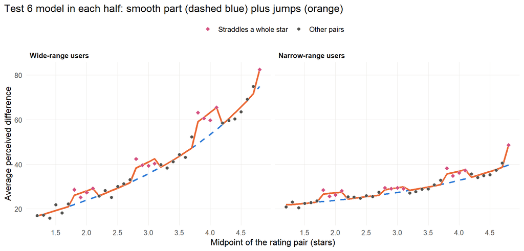

```r
grp_plot <- bind_rows(lapply(names(grp_runs), function(g) {
  L <- grp_runs[[g]]; f <- L$fits$beta; Yg <- Ymat[, grp_ids[[g]]]
  a <- round(xs - 0.2, 1); b <- round(xs + 0.2, 1)
  tibble(group = g, x = xs, m = rowMeans(Yg), full = f$fitted,
         smooth = f$coef[["offset"]] + f$coef[["lambda"]] * perf(a, b, f$grid$c)) |>
    left_join(select(mean_curve, x, pt_type), by = "x")
})) |> mutate(group = factor(group, levels = names(grp_runs)))
ggplot(grp_plot) +
  geom_line(aes(x, smooth), color = blue, linewidth = 0.9, linetype = "dashed") +
  geom_line(aes(x, full), color = orange, linewidth = 1.1) +
  geom_point(aes(x, m, fill = pt_type, shape = pt_type), color = "#fcfcfb", stroke = 0.4, size = 2) +
  scale_fill_manual(values = setNames(c(magenta, ink2), cross_levels), name = NULL) +
  scale_shape_manual(values = setNames(c(23, 21), cross_levels), name = NULL) +
  facet_wrap(~ group) +
  scale_x_continuous(breaks = seq(1, 5, 0.5)) +
  labs(x = "Midpoint of the rating pair (stars)", y = "Average perceived difference",
       title = "Test 6 model in each half: smooth part (dashed blue) plus jumps (orange)") +
  theme_pod
```

**Result.**

- **Rising sensitivity does not depend on slider use.** Sensitivity is about twice as high at the top as at the bottom in both groups (2.1 and 2.2), even though wide-range users’ answers rise 65 points from bottom to top and narrow-range users’ only 28 points.
- **Jumps at whole stars appear in both groups.**
- **The extra-large 4-star jump is clear only among wide-range users.** Their 4-star jump is 2.1 times the average of the 2- and 3-star jumps (*p* < .0005 for a difference). For narrow-range users it is 1.5 times, with an interval that includes 1 (*p* = .077). The difference between the groups is itself uncertain (*p* = .247). Narrow-range users’ smaller answers carry less signal relative to noise, so this may mean the effect is harder to detect in them rather than absent. Either way, the special status of 4 stars rests more heavily on wide-range users than the other findings do.

### Ratios within each person

**Question.** If every person’s answers are put on their own scale, so wide- and narrow-range users count equally, do the Test 6 results still hold?

**Why this check.** Each answer is divided by that person’s own average across the 37 pairs. A value of 1.3 then means “this pair felt 30% more different than this person’s typical pair”, whatever part of the slider they used. The average is used as the reference rather than one answer (such as the first pair) because a single answer is noisy and often near 0: 12 people answered 0 for 1.0 vs 1.4, which would make their ratios impossible. Only 1 person has an average below 5. Ratios can still be extreme for a few people, so the main version combines people by the **median** at each pair; the mean is shown for comparison.

```r
rel_row <- function(s, label) tibble(
  Version = label,
  `Sensitivity ratio` = sprintf("%.1f (%s)", s$sens, ci(s$sens_draws)),
  `4-star ratio` = sprintf("%.1f (%s)", s$j4, ci(s$j4_draws)),
  `4-star jump minus avg. of 2 and 3` = paste0("p ", pb_eq(s$j4_minus)))
bind_rows(rel_row(raw_sum, "Raw answers, mean (main analysis)"),
          rel_row(rel_sum[[1]], "Ratios to own average, median"),
          rel_row(rel_sum[[2]], "Ratios to own average, mean")) |>
  kable(align = "lrrr", caption = "Slider-free measures under each version (95% bootstrap intervals in brackets)")
```

Slider-free measures under each version (95% bootstrap intervals in brackets)

| Version | Sensitivity ratio | 4-star ratio | 4-star jump minus avg. of 2 and 3 |
| --- | --- | --- | --- |
| Raw answers, mean (main analysis) | 2.1 (1.7 to 2.6) | 1.9 (1.5 to 2.6) | p < .0005 |
| Ratios to own average, median | 2.1 (1.6 to 2.8) | 1.6 (1.2 to 2.4) | p = .004 |
| Ratios to own average, mean | 2.2 (1.7 to 2.7) | 1.9 (1.4 to 2.6) | p < .0005 |

**Jump sizes on the ratio scale** (median version): how much more different a pair that crosses a whole star feels, as a percentage of a person’s typical difference.

```r
s <- rel_sum[[1]]
tibble(`Whole star` = c("2", "3", "4", "5 (also the end of the scale)"),
       Jump = sapply(2:5, \(k) sprintf("%.0f%%", 100 * s$fit$coef[[paste0("beta", k)]])),
       `95% CI` = sapply(2:5, \(k) { v <- 100 * s$boot[[paste0("beta", k)]]
                                    sprintf("%.0f%% to %.0f%%", quantile(v, .025), quantile(v, .975)) })) |>
  kable(align = "lrr")
```

| Whole star | Jump | 95% CI |
| --- | --- | --- |
| 2 | 10% | 6% to 14% |
| 3 | 11% | 6% to 15% |
| 4 | 17% | 12% to 23% |
| 5 (also the end of the scale) | 29% | 17% to 41% |

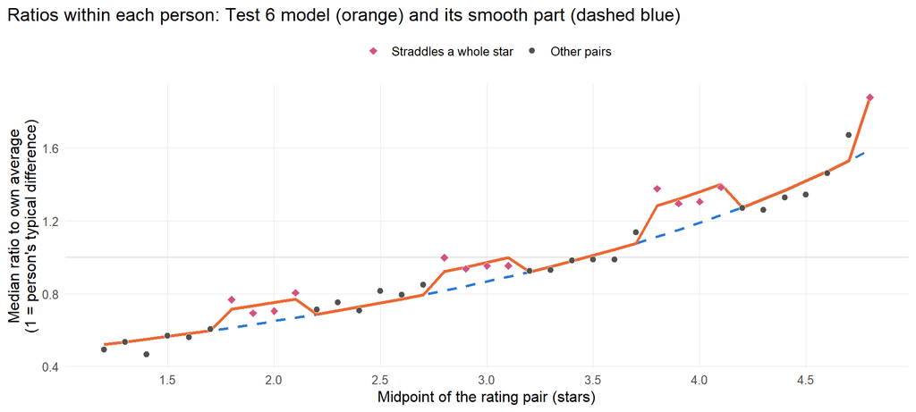

```r
L <- rel_runs[[1]]; f <- L$fits$beta
a <- round(xs - 0.2, 1); b <- round(xs + 0.2, 1)
tibble(x = xs, m = row_median(Ymat_rel), full = f$fitted,
       smooth = f$coef[["offset"]] + f$coef[["lambda"]] * perf(a, b, f$grid$c)) |>
  left_join(select(mean_curve, x, pt_type), by = "x") |>
  ggplot() +
  geom_hline(yintercept = 1, color = grid_c, linewidth = 0.6) +
  geom_line(aes(x, smooth), color = blue, linewidth = 0.9, linetype = "dashed") +
  geom_line(aes(x, full), color = orange, linewidth = 1.1) +
  geom_point(aes(x, m, fill = pt_type, shape = pt_type), color = "#fcfcfb", stroke = 0.4, size = 2.2) +
  scale_fill_manual(values = setNames(c(magenta, ink2), cross_levels), name = NULL) +
  scale_shape_manual(values = setNames(c(23, 21), cross_levels), name = NULL) +
  scale_x_continuous(breaks = seq(1, 5, 0.5)) +
  labs(x = "Midpoint of the rating pair (stars)",
       y = "Median ratio to own average\n(1 = person's typical difference)",
       title = "Ratios within each person: Test 6 model (orange) and its smooth part (dashed blue)") +
  theme_pod
```

# Part 4: Caveats

- **The average curve blends people.** If participants put their boundaries in slightly different places, averaging smears each person’s sharp step into a gentler slope. The breaks describe the *average* curve, not necessarily any one person. Individual boundaries were too noisy to estimate one person at a time (`pod1_analysis.qmd`).
- **Regions are not labels.** The models find where the curve changes. Calling regions negative, neutral or positive is an interpretation.
- **Straight lines cannot represent the whole-star bumps.** Region slopes average over them, so a slope that differs from 0 does not by itself mean perception changes smoothly within the region.
- **Responses are not independent.** The bootstrap and prediction test resample whole participants, which respects that each person gave 37 related answers.
- **The β-δ model is a borrowed structure, not a claim about discounting.** It is used because it cleanly separates a smooth change in sensitivity from one-off jumps. “Distance from perfect” is one convenient smooth shape; others that rise toward the top might fit similarly.
- **The jump at 5 stars and the end of the scale cannot be separated.** Only one pair (4.6 vs 5.0) crosses 5, and it is also the last pair on the scale.
- **The model describes the average person.** Individuals may differ in how strongly they react to whole stars, and the average jump can hide that.

# Appendix

## A. Elbow models (lines that bend but cannot jump)

The elbow models fit worse than the step models in both comparisons above (Test 3), so they are not part of the main results. Their fits, breaks and slopes are shown here for completeness.

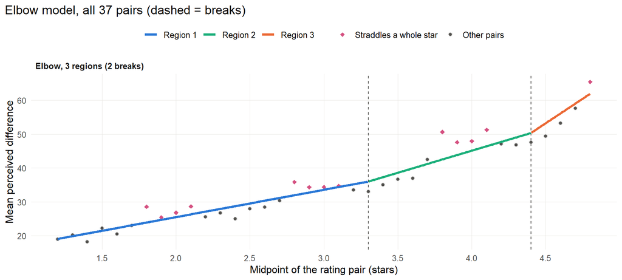

```r
plot_fits(R_all, "elbow2", "Elbow model, all 37 pairs (dashed = breaks)")
```

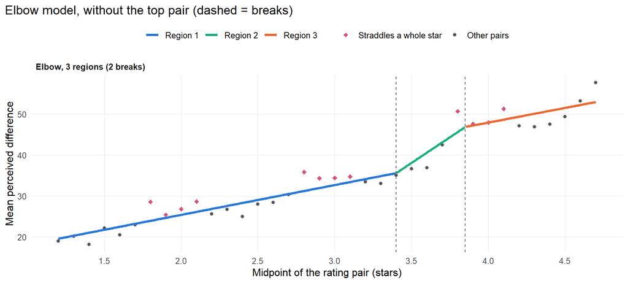

```r
plot_fits(R_cut, "elbow2", "Elbow model, without the top pair (dashed = breaks)")
```

```r
show_breaks(R_all, "elbow2")
```

| Model | Break | Best estimate | 95% range | Same spot | Within 0.1 star | At the allowed limit |
| --- | --- | --- | --- | --- | --- | --- |
| Elbow, 3 regions (2 breaks) | Lower break | 3.30 | 2.45-3.40 | 38% | 84% | 0% |
| Elbow, 3 regions (2 breaks) | Upper break | 4.40 | 3.85-4.40 | 77% | 77% | 77% |

```r
show_slopes(R_all, "elbow2")
```

| Model | Region | Span (stars) | Slope | 95% CI | p | Differs from 0? |
| --- | --- | --- | --- | --- | --- | --- |
| Elbow, 3 regions (2 breaks) | Region 1 | 1.20-3.30 | 8.1 | 6.2 to 9.4 | < .0005 | yes |
| Elbow, 3 regions (2 breaks) | Region 2 | 3.30-4.40 | 13.1 | 9.8 to 25.7 | .012 | yes |
| Elbow, 3 regions (2 breaks) | Region 3 | 4.40-4.80 | 29.0 | 9.9 to 36.8 | < .0005 | yes |

```r
show_breaks(R_cut, "elbow2")
```

| Model | Break | Best estimate | 95% range | Same spot | Within 0.1 star | At the allowed limit |
| --- | --- | --- | --- | --- | --- | --- |
| Elbow, 3 regions (2 breaks) | Lower break | 3.40 | 3.40-3.50 | 88% | 100% | 0% |
| Elbow, 3 regions (2 breaks) | Upper break | 3.85 | 3.85-3.95 | 88% | 100% | 0% |

```r
show_slopes(R_cut, "elbow2")
```

| Model | Region | Span (stars) | Slope | 95% CI | p | Differs from 0? |
| --- | --- | --- | --- | --- | --- | --- |
| Elbow, 3 regions (2 breaks) | Region 1 | 1.20-3.40 | 7.3 | 6.2 to 8.4 | < .0005 | yes |
| Elbow, 3 regions (2 breaks) | Region 2 | 3.40-3.85 | 25.0 | 21.3 to 29.2 | .002 | yes |
| Elbow, 3 regions (2 breaks) | Region 3 | 3.85-4.70 | 7.2 | 3.4 to 10.2 | .001 | yes |

## B. Slope checks

Two further checks of the region slopes:

- **Mixed model:** all individual responses at the chosen breaks, with each participant allowed their own intercept and region slopes. Its *p*-values treat the breaks as known in advance, so they are somewhat too optimistic.
- **Split-half:** breaks are found in a random half of participants (A), and the slopes are tested only in the other half (B), whose data played no part in placing them.

**All 37 pairs**

```r
show_checks(R_all, detail_keys)
```

| Model | Check | Region | Slope | SE | p |
| --- | --- | --- | --- | --- | --- |
| Step, 2 regions (1 break) | Mixed model, all participants | Region 1 | 7.5 | 0.6 | < .001 |
| Step, 2 regions (1 break) | Mixed model, all participants | Region 2 | 12.2 | 1.4 | < .001 |
| Step, 2 regions (1 break) | Split-half (breaks 4.25 from half A) | Region 1 | 10.3 | 0.8 | < .001 |
| Step, 2 regions (1 break) | Split-half (breaks 4.25 from half A) | Region 2 | 34.5 | 3.9 | < .001 |
| Step, 3 regions (2 breaks) | Mixed model, all participants | Region 1 | 7.9 | 0.6 | < .001 |
| Step, 3 regions (2 breaks) | Mixed model, all participants | Region 2 | -5.0 | 2.6 | .055 |
| Step, 3 regions (2 breaks) | Mixed model, all participants | Region 3 | 44.1 | 3.9 | < .001 |
| Step, 3 regions (2 breaks) | Split-half (breaks 3.75, 4.35 from half A) | Region 1 | 8.0 | 0.7 | < .001 |
| Step, 3 regions (2 breaks) | Split-half (breaks 3.75, 4.35 from half A) | Region 2 | 0.2 | 3.7 | .961 |
| Step, 3 regions (2 breaks) | Split-half (breaks 3.75, 4.35 from half A) | Region 3 | 43.0 | 5.4 | < .001 |
| Elbow, 3 regions (2 breaks) | Mixed model, all participants | Region 1 | 8.1 | 0.6 | < .001 |
| Elbow, 3 regions (2 breaks) | Mixed model, all participants | Region 2 | 13.1 | 1.2 | < .001 |
| Elbow, 3 regions (2 breaks) | Mixed model, all participants | Region 3 | 29.0 | 3.3 | < .001 |
| Elbow, 3 regions (2 breaks) | Split-half (breaks 3.90, 4.40 from half A) | Region 1 | 9.9 | 0.8 | < .001 |
| Elbow, 3 regions (2 breaks) | Split-half (breaks 3.90, 4.40 from half A) | Region 2 | 14.4 | 3.2 | < .001 |
| Elbow, 3 regions (2 breaks) | Split-half (breaks 3.90, 4.40 from half A) | Region 3 | 35.1 | 4.6 | < .001 |

**Without the top pair**

```r
show_checks(R_cut, detail_keys)
```

| Model | Check | Region | Slope | SE | p |
| --- | --- | --- | --- | --- | --- |
| Step, 2 regions (1 break) | Mixed model, all participants | Region 1 | 7.5 | 0.6 | < .001 |
| Step, 2 regions (1 break) | Mixed model, all participants | Region 2 | 7.8 | 1.5 | < .001 |
| Step, 2 regions (1 break) | Split-half (breaks 3.65 from half A) | Region 1 | 7.6 | 0.7 | < .001 |
| Step, 2 regions (1 break) | Split-half (breaks 3.65 from half A) | Region 2 | 10.9 | 2.0 | < .001 |
| Step, 3 regions (2 breaks) | Mixed model, all participants | Region 1 | 7.9 | 0.6 | < .001 |
| Step, 3 regions (2 breaks) | Mixed model, all participants | Region 2 | -3.5 | 3.3 | .290 |
| Step, 3 regions (2 breaks) | Mixed model, all participants | Region 3 | 27.3 | 3.8 | < .001 |
| Step, 3 regions (2 breaks) | Split-half (breaks 3.75, 4.25 from half A) | Region 1 | 8.0 | 0.7 | < .001 |
| Step, 3 regions (2 breaks) | Split-half (breaks 3.75, 4.25 from half A) | Region 2 | -0.6 | 4.6 | .895 |
| Step, 3 regions (2 breaks) | Split-half (breaks 3.75, 4.25 from half A) | Region 3 | 26.0 | 5.0 | < .001 |
| Elbow, 3 regions (2 breaks) | Mixed model, all participants | Region 1 | 7.3 | 0.6 | < .001 |
| Elbow, 3 regions (2 breaks) | Mixed model, all participants | Region 2 | 25.0 | 2.2 | < .001 |
| Elbow, 3 regions (2 breaks) | Mixed model, all participants | Region 3 | 7.2 | 1.6 | < .001 |
| Elbow, 3 regions (2 breaks) | Split-half (breaks 3.40, 3.85 from half A) | Region 1 | 7.3 | 0.7 | < .001 |
| Elbow, 3 regions (2 breaks) | Split-half (breaks 3.40, 3.85 from half A) | Region 2 | 27.0 | 3.2 | < .001 |
| Elbow, 3 regions (2 breaks) | Split-half (breaks 3.40, 3.85 from half A) | Region 3 | 10.3 | 2.2 | < .001 |

In the 2-region model with all pairs, half A placed its break at the top of the scale instead of near 4 stars, so its split-half row tests different regions.

**2-region step model: bootstrap slopes.** Both slopes are positive, but the second region lumps the flat stretch around 4 stars together with the climb to 5, so its slope averages over two different patterns.

All 37 pairs:

```r
show_slopes(R_all, "step1")
```

| Model | Region | Span (stars) | Slope | 95% CI | p | Differs from 0? |
| --- | --- | --- | --- | --- | --- | --- |
| Step, 2 regions (1 break) | Region 1 | 1.20-3.65 | 7.5 | 6.5 to 10.4 | < .0005 | yes |
| Step, 2 regions (1 break) | Region 2 | 3.65-4.80 | 12.2 | 9.3 to 50.7 | < .0005 | yes |

Without the top pair:

```r
show_slopes(R_cut, "step1")
```

| Model | Region | Span (stars) | Slope | 95% CI | p | Differs from 0? |
| --- | --- | --- | --- | --- | --- | --- |
| Step, 2 regions (1 break) | Region 1 | 1.20-3.65 | 7.5 | 6.4 to 8.7 | < .0005 | yes |
| Step, 2 regions (1 break) | Region 2 | 3.65-4.70 | 7.8 | 2.9 to 10.3 | .001 | yes |

## C. Average response for every pair

```r
mean_curve |>
  transmute(Pair = sprintf("%.1f vs %.1f", x - 0.2, x + 0.2), Midpoint = sprintf("%.1f", x),
            `Straddles a whole star?` = ifelse(cross, paste0("yes (", floor(round(x + 0.2, 1)), ")"), ""),
            Mean = round(m, 1), `95% CI` = sprintf("%.1f-%.1f", lo, hi)) |>
  kable(align = "llcrr")
```

| Pair | Midpoint | Straddles a whole star? | Mean | 95% CI |
| --- | --- | --- | --- | --- |
| 1.0 vs 1.4 | 1.2 |  | 19.0 | 16.5-21.4 |
| 1.1 vs 1.5 | 1.3 |  | 20.2 | 17.6-22.7 |
| 1.2 vs 1.6 | 1.4 |  | 18.2 | 16.1-20.3 |
| 1.3 vs 1.7 | 1.5 |  | 22.2 | 19.5-24.8 |
| 1.4 vs 1.8 | 1.6 |  | 20.5 | 18.2-22.8 |
| 1.5 vs 1.9 | 1.7 |  | 23.0 | 20.6-25.3 |
| 1.6 vs 2.0 | 1.8 | yes (2) | 28.6 | 25.9-31.3 |
| 1.7 vs 2.1 | 1.9 | yes (2) | 25.4 | 22.9-28.0 |
| 1.8 vs 2.2 | 2.0 | yes (2) | 26.8 | 24.2-29.5 |
| 1.9 vs 2.3 | 2.1 | yes (2) | 28.7 | 26.0-31.3 |
| 2.0 vs 2.4 | 2.2 |  | 25.6 | 23.6-27.6 |
| 2.1 vs 2.5 | 2.3 |  | 26.7 | 24.6-28.9 |
| 2.2 vs 2.6 | 2.4 |  | 25.0 | 22.8-27.2 |
| 2.3 vs 2.7 | 2.5 |  | 28.0 | 25.7-30.3 |
| 2.4 vs 2.8 | 2.6 |  | 28.4 | 25.9-31.0 |
| 2.5 vs 2.9 | 2.7 |  | 30.4 | 27.8-32.9 |
| 2.6 vs 3.0 | 2.8 | yes (3) | 35.9 | 33.1-38.7 |
| 2.7 vs 3.1 | 2.9 | yes (3) | 34.3 | 31.5-37.2 |
| 2.8 vs 3.2 | 3.0 | yes (3) | 34.4 | 31.8-37.0 |
| 2.9 vs 3.3 | 3.1 | yes (3) | 34.7 | 32.0-37.4 |
| 3.0 vs 3.4 | 3.2 |  | 33.5 | 30.9-36.0 |
| 3.1 vs 3.5 | 3.3 |  | 33.0 | 30.5-35.5 |
| 3.2 vs 3.6 | 3.4 |  | 35.0 | 32.4-37.7 |
| 3.3 vs 3.7 | 3.5 |  | 36.6 | 33.7-39.5 |
| 3.4 vs 3.8 | 3.6 |  | 36.9 | 34.0-39.8 |
| 3.5 vs 3.9 | 3.7 |  | 42.5 | 39.3-45.8 |
| 3.6 vs 4.0 | 3.8 | yes (4) | 50.7 | 47.2-54.2 |
| 3.7 vs 4.1 | 3.9 | yes (4) | 47.6 | 44.2-51.0 |
| 3.8 vs 4.2 | 4.0 | yes (4) | 47.9 | 44.5-51.4 |
| 3.9 vs 4.3 | 4.1 | yes (4) | 51.3 | 47.6-54.9 |
| 4.0 vs 4.4 | 4.2 |  | 47.1 | 43.7-50.4 |
| 4.1 vs 4.5 | 4.3 |  | 46.8 | 43.5-50.2 |
| 4.2 vs 4.6 | 4.4 |  | 47.5 | 44.1-51.0 |
| 4.3 vs 4.7 | 4.5 |  | 49.4 | 45.7-53.1 |
| 4.4 vs 4.8 | 4.6 |  | 53.2 | 49.2-57.2 |
| 4.5 vs 4.9 | 4.7 |  | 57.6 | 53.3-62.0 |
| 4.6 vs 5.0 | 4.8 | yes (5) | 65.5 | 61.2-69.8 |

## D. Whole-star bumps on a straight-line trend (earlier version of Test 6)

An earlier version of the whole-star analysis, kept for transparency. It assumed sensitivity rises in a **straight line** across the scale. Test 6 shows that a curved rise fits much better, and under the curved rise the jumps at 2 and 3 stars are equal. The small 3-star bump below is therefore mostly an artifact of the straight-line assumption.

This model fits one model to all individual responses with three parts: an overall upward trend, a separate **bump** for each whole star crossed, and a term for the top pair. The top pair crosses 5 *and* sits at the end of the scale, so those two cannot be separated. Each person has their own baseline and overall slope.

```r
tibble(Term = c("Overall trend (points per star)", "Crossing 2 stars", "Crossing 3 stars",
                "Crossing 4 stars", "Top pair (crosses 5; end of scale)"),
       key = c("x", "cross2", "cross3", "cross4", "top")) |>
  mutate(Estimate = sprintf("%.1f", ws_co[key, "Estimate"]),
         `95% CI` = sprintf("%.1f to %.1f", ws_co[key, "Estimate"] - 1.96 * ws_co[key, "Std. Error"],
                            ws_co[key, "Estimate"] + 1.96 * ws_co[key, "Std. Error"]),
         p = fmt_p(ws_co[key, "Pr(>|t|)"])) |>
  select(-key) |>
  kable(align = "lrrr", caption = "Extra points on the 0-100 slider")
```

Extra points on the 0-100 slider

| Term | Estimate | 95% CI | p |
| --- | --- | --- | --- |
| Overall trend (points per star) | 9.9 | 8.7 to 11.0 | < .001 |
| Crossing 2 stars | 3.6 | 2.6 to 4.7 | < .001 |
| Crossing 3 stars | 1.2 | 0.2 to 2.2 | .015 |
| Crossing 4 stars | 5.9 | 4.9 to 7.0 | < .001 |
| Top pair (crosses 5; end of scale) | 13.6 | 11.7 to 15.6 | < .001 |

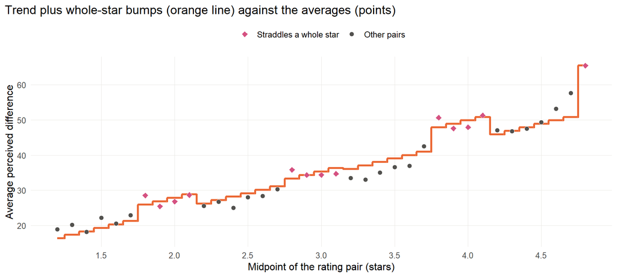

```r
ws_pred <- long_ws |> distinct(x, cross2, cross3, cross4, top) |> arrange(x)
fe <- lme4::fixef(ws_each)
ws_pred$yhat <- fe["(Intercept)"] + fe["x"] * ws_pred$x + fe["cross2"] * ws_pred$cross2 +
  fe["cross3"] * ws_pred$cross3 + fe["cross4"] * ws_pred$cross4 + fe["top"] * ws_pred$top
ggplot() +
  geom_step(data = ws_pred, aes(x, yhat), color = orange, linewidth = 1.1, direction = "mid") +
  cross_points(mean_curve, 2.4) +
  scale_x_continuous(breaks = seq(1, 5, 0.5)) +
  labs(x = "Midpoint of the rating pair (stars)", y = "Average perceived difference",
       title = "Trend plus whole-star bumps (orange line) against the averages (points)") +
  theme_pod
```

**Result.**